# Final Project

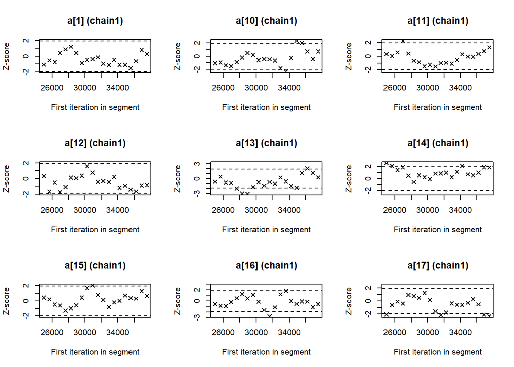

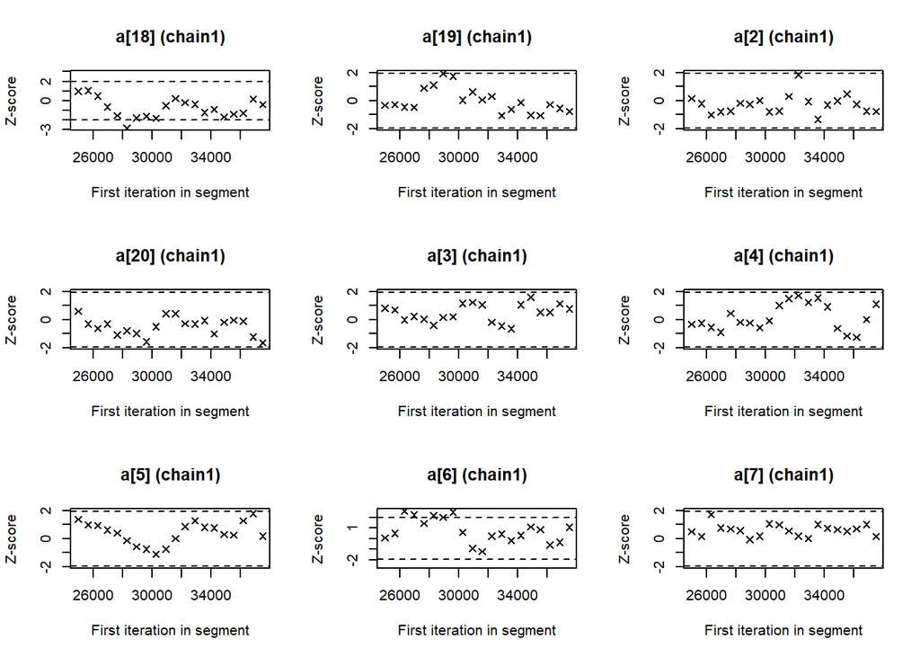

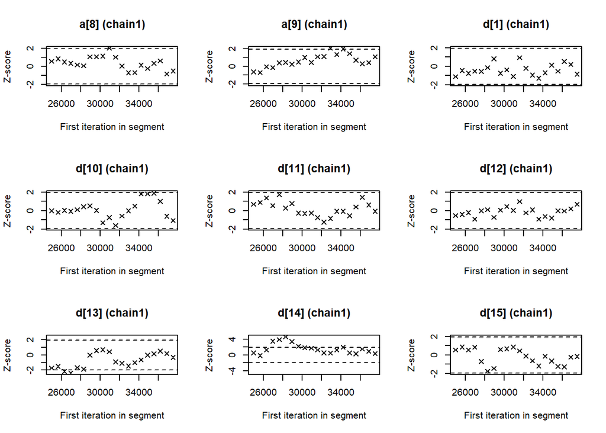

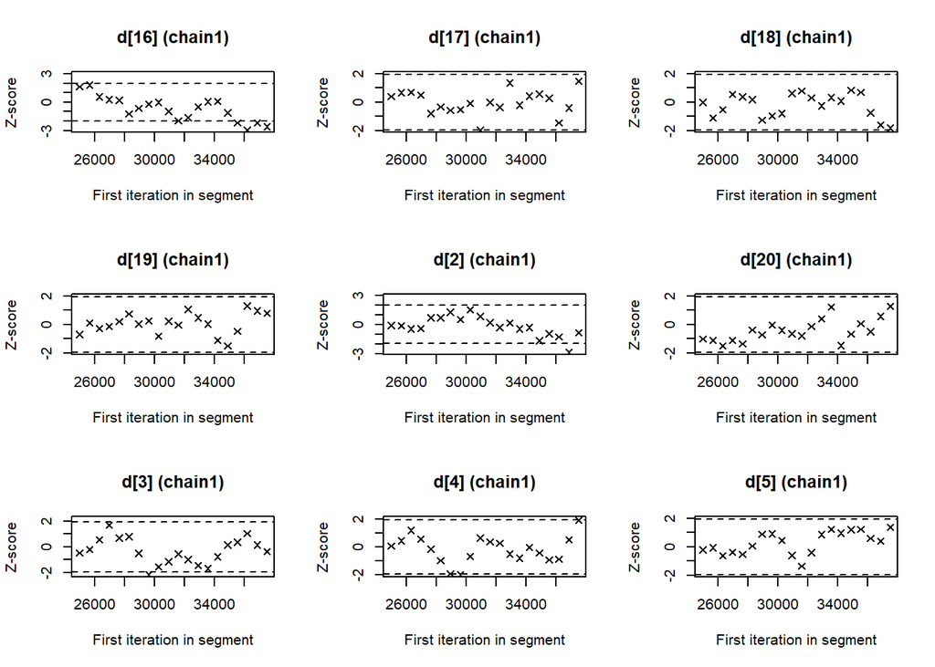

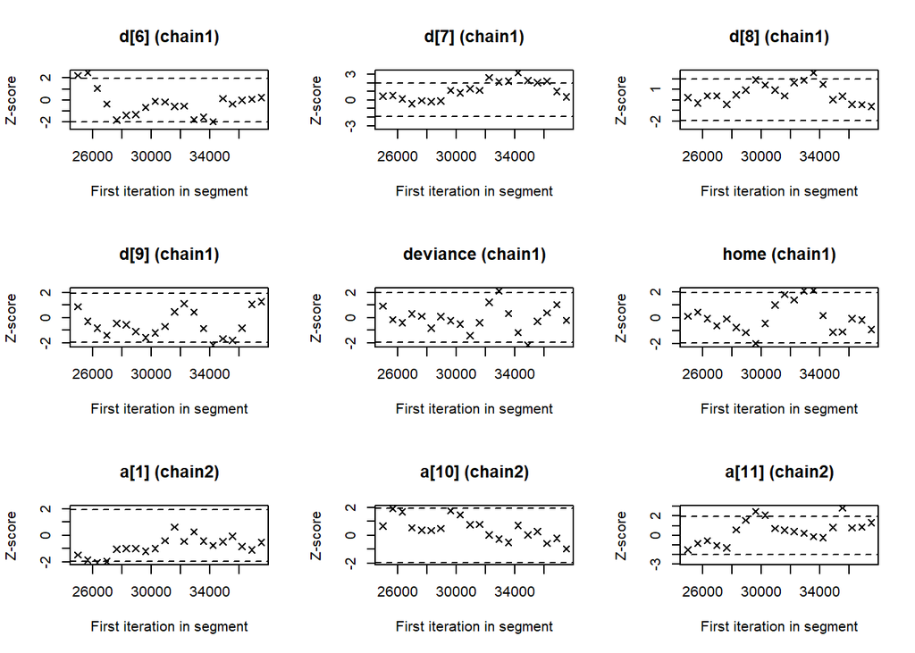

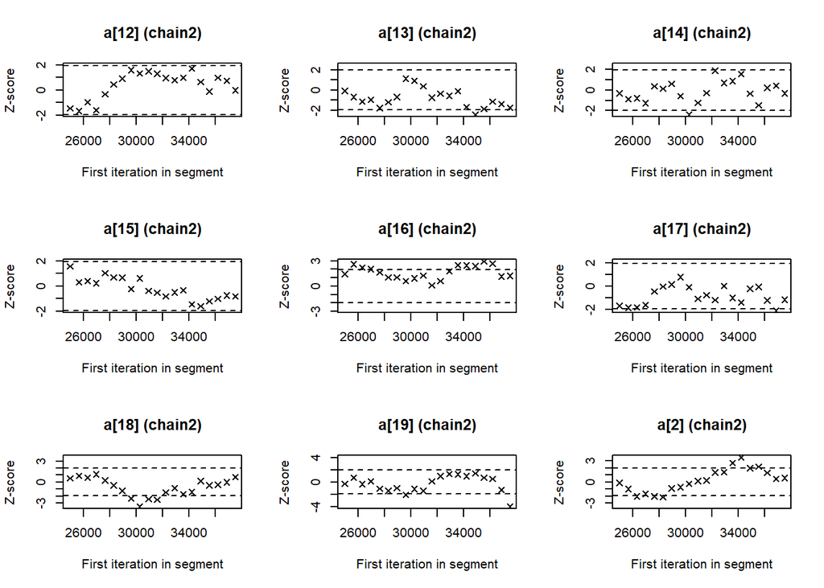

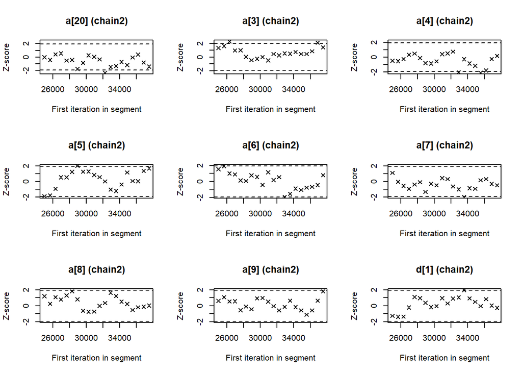

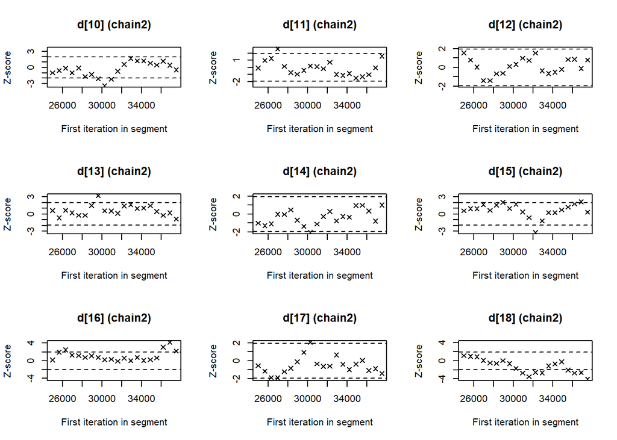

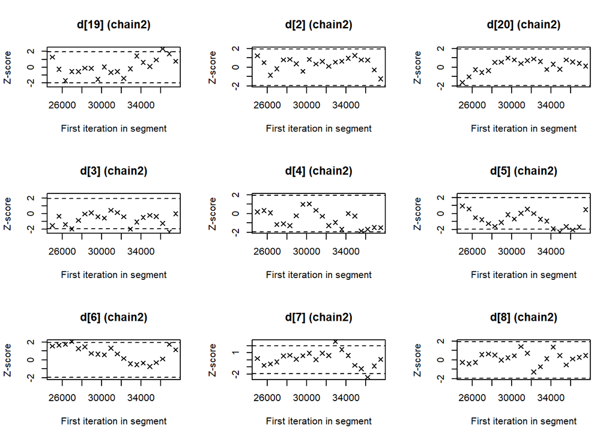

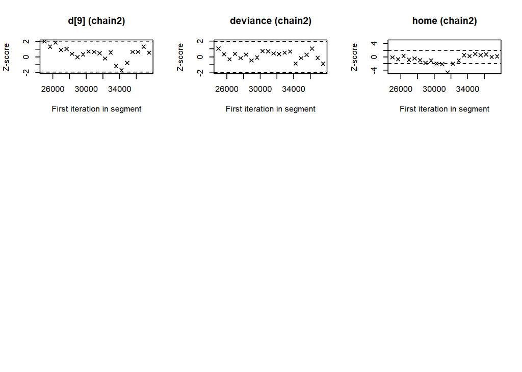

```r
geweke.plot(log.j)
```

# HPD - Highest Posterior Density Intervals

A $(1-\alpha)\%$ HPD interval is a region that satisfies the following two conditions:

1.The posterior probability of that region is $(1-\alpha)\%$.

2.The minimum density of any point within that region is equal to or larger than the density of any point outside that region. So it’s possible to say that HPD interval is the collection of most likely values of the parameters.

**THE HPD is an interval only when the parameter is unidimensional and the posterior is unimodal.**

Observing the values of the HPD we will notice that they will generate narrower intervals than those of the equal tail that are present in the model summary.

Highest Posterior Density (HPD) intervals for $90$, $95$, and $99$ percent intervals assuming that the data is not severely multimodal, as we have seen in the *density plots*.

```r
list(int90 = HPDinterval(mm1[[1]], prob=.90), int95= HPDinterval(mm1[[1]], prob=.95), int99= HPDinterval(mm1[[1]], prob=.99))
```

```
## $int90
##                  lower         upper
## a[1]       -0.05988692    0.36944626
## a[10]       0.40853194    0.75995987
## a[11]       0.45187468    0.79455752
## a[12]      -0.05187737    0.39420000
## a[13]       0.29556290    0.64952426
## a[14]      -0.01669741    0.42116858
## a[15]      -0.03692932    0.38060069
## a[16]      -0.86045025   -0.23265489
## a[17]      -0.44123453    0.06030303
## a[18]      -0.08852381    0.33210057
## a[19]      -0.21436920    0.27509216
## a[2]       -0.61814916   -0.06153559
## a[20]      -0.77652353   -0.15909055
## a[3]       -0.43725350    0.08098622
## a[4]       -0.72634842   -0.12853425
## a[5]       -0.57456993   -0.02626645
## a[6]       -0.41735369    0.08898557
## a[7]       -0.11082273    0.33455289
## a[8]       -0.67239532   -0.13771318
## a[9]        0.12379437    0.54061261
## d[1]       -0.45373896    0.05999239
## d[10]      -1.00123011   -0.35824310
## d[11]      -0.18151152    0.27460162
## d[12]      -0.39251662    0.09158110
## d[13]      -0.83232838   -0.22594138
## d[14]      -0.89607428   -0.26000791
## d[15]       0.02732467    0.44104508
## d[16]      -0.04825062    0.39395256
## d[17]      -0.01178501    0.41114605
## d[18]      -0.27511593    0.20379523
## d[19]       0.05644809    0.47425398
## d[2]        0.37439662    0.72508746
## d[20]       0.28991463    0.66275897
## d[3]       -0.17241874    0.28009473
## d[4]        0.02015764    0.44056184
## d[5]       -0.02231563    0.39862691
## d[6]        0.12268019    0.53812953
## d[7]       -0.28057932    0.21277353
```

[output cut: 85 more lines]

```
## d[18]      -0.40792627    0.31716495
## d[19]      -0.05774166    0.59605777
## d[2]        0.27076390    0.82868375
## d[20]       0.19978640    0.76177388
## d[3]       -0.28361807    0.39034315
## d[4]       -0.08991292    0.57004521
## d[5]       -0.13726833    0.54373331
## d[6]       -0.01252835    0.62956237
## d[7]       -0.38290497    0.34531175
## d[8]       -0.54021837    0.22320254
## d[9]       -0.98715434    0.01648093
## deviance 2113.86108074 2163.98843556
## home        0.11877663    0.34404794
## attr(,"Probability")
## [1] 0.99
```

Now we can evaluate the **posterior uncertainty**:

```r
xx <- NULL
for(i in 1:dim(model_1$BUGSoutput$sims.array)[3])
{
H_intervallo <- HPDinterval(mm1[[1]], prob=.90)[i,]
post_uncc <- unname((H_intervallo[2]-H_intervallo[1])/(max(model_1$BUGSoutput$sims.array[,1,i])-min(model_1$BUGSoutput$sims.array[,1,i])))

xx[i] <- post_uncc
}

posss <- which.max(xx)
MINN <- which.min(xx[c(1:40,42)])


par_list[MINN]
```

```
## [1] "a[1]"
```

```r
c("Diff" = unname(abs(HPDinterval(mm1[[1]], prob=.90)[MINN,][2] - HPDinterval(mm1[[1]], prob=.90)[MINN,][1])))
```

```
##      Diff
## 0.4293332
```

```r
par_list[posss]
```

```
## [1] "d[10]"
```

```r
c("Diff" = unname(abs(HPDinterval(mm1[[1]], prob=.90)[posss,][2] - HPDinterval(mm1[[1]], prob=.90)[posss,][1])))
```

```
##     Diff
## 0.642987
```

Let’s take a look:

In the first graph we observe the parameter with **less uncertainty**.

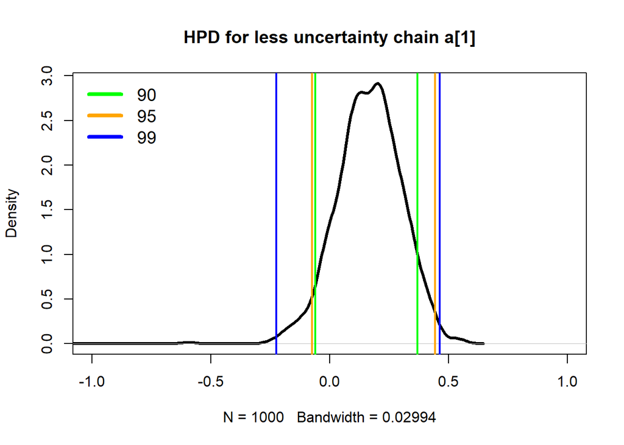

```r
plot(density(model_1$BUGSoutput$sims.array[,,MINN][,1]), col='black', lwd=3, main="HPD for less uncertainty chain a[1]",xlim=c(-1,+1))
abline(v=HPDinterval(mm1[[1]], prob=.90)[MINN,], col='green', lwd=2)
abline(v=HPDinterval(mm1[[1]], prob=.95)[MINN,], col='orange', lwd=2)
abline(v=HPDinterval(mm1[[1]], prob=.99)[MINN,], col='blue', lwd=2)
legend(x="topleft", legend=c("90","95","99"), col=c("green","orange","blue"), bty = 'n', lwd=4, cex=1.2)
```

In the second we focus on the parameter **with greater uncertainty**.

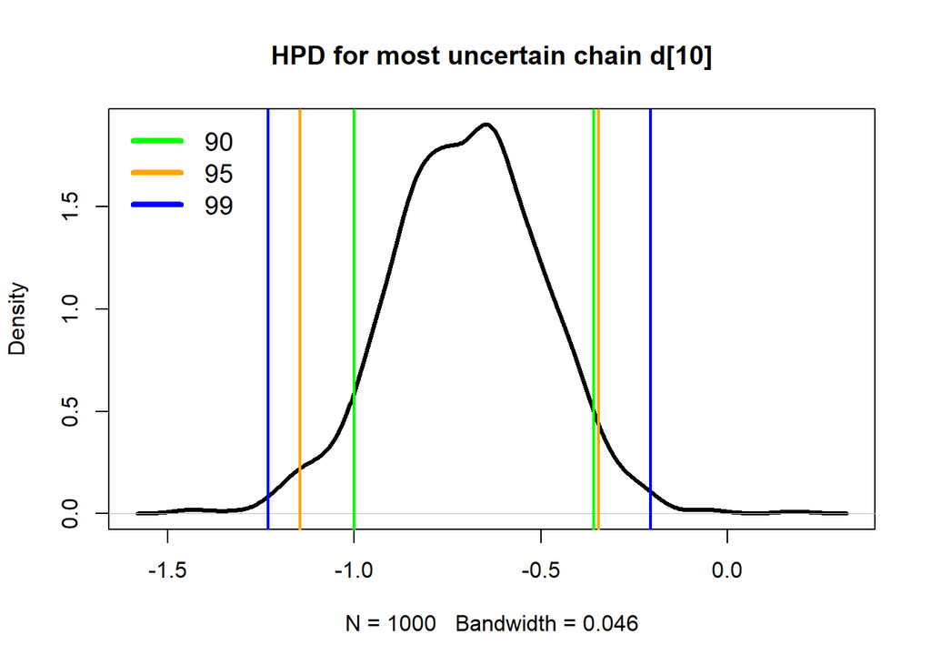

```r
plot(density(model_1$BUGSoutput$sims.array[,,30][,1]), col='black', lwd=3, main="HPD for most uncertain chain d[10]")
abline(v=HPDinterval(mm1[[1]], prob=.90)[posss,], col='green', lwd=2)
abline(v=HPDinterval(mm1[[1]], prob=.95)[posss,], col='orange', lwd=2)
abline(v=HPDinterval(mm1[[1]], prob=.99)[posss,], col='blue', lwd=2)
legend(x="topleft", legend=c("90","95","99"), col=c("green","orange","blue"), bty = 'n', lwd=4, cex=1.2)
```

### ESS - Effective Sample Size

$n_{eff}$ is a function of the correlation between observations in the sample :

$n_{eff}= \frac{n}{1+2 \sum_{k=1}^{n}\rho_{k}}$

```r
lapply(log.j,effectiveSize)
```

```
## [[1]]
##      a[1]     a[10]     a[11]     a[12]     a[13]     a[14]     a[15]
##  753.1908  771.4746 1327.8207  861.2633 1000.0000  881.4885 1000.0000
##     a[16]     a[17]     a[18]     a[19]      a[2]     a[20]      a[3]
##  653.2489  785.2758 1000.0000  813.7173  701.6336  709.8541  987.2004
##      a[4]      a[5]      a[6]      a[7]      a[8]      a[9]      d[1]
##  731.1351  743.8510  755.8025  825.3900  725.7007  907.5201  773.4074
##     d[10]     d[11]     d[12]     d[13]     d[14]     d[15]     d[16]
##  693.4902  792.0130  987.8700  751.5307  828.7167 1000.0000 1000.0000
##     d[17]     d[18]     d[19]      d[2]     d[20]      d[3]      d[4]
##  793.3838  811.7635  865.3805 1023.3571 1242.1716  866.8007  970.8696
##      d[5]      d[6]      d[7]      d[8]      d[9]  deviance      home
##  880.9325  911.2205 1000.0000  783.2147  735.1992 1000.0000  835.2659
##
## [[2]]
##      a[1]     a[10]     a[11]     a[12]     a[13]     a[14]     a[15]
## 1000.0000 1000.0000  837.3940  904.1230  824.2927  581.8902  805.1854
##     a[16]     a[17]     a[18]     a[19]      a[2]     a[20]      a[3]
##  664.6855  847.7310  801.4719  726.0490  757.4988  705.0888  802.0021
##      a[4]      a[5]      a[6]      a[7]      a[8]      a[9]      d[1]
##  784.8507  776.2229  721.8784  823.6267  775.0730  893.4994  696.1525
##     d[10]     d[11]     d[12]     d[13]     d[14]     d[15]     d[16]
##  651.0301  788.7643  787.3653  731.7463  707.9786  885.7956  888.7995
##     d[17]     d[18]     d[19]      d[2]     d[20]      d[3]      d[4]
##  821.3388  652.1832  884.8329 1145.2016 1000.0000  858.4107  847.7220
##      d[5]      d[6]      d[7]      d[8]      d[9]  deviance      home
##  865.1299  893.7572  797.5354  857.6565  688.8110  907.5711  822.4501
```

# Data Generated

Until now we have evaluated the behaviour of our model assuming that the data were derived from a Poisson, but we can check our model. In fact, by generating the values of attack and defense of the 20 teams in the league taking them as true values we try to observe the behaviour of the model when actually the data were generated by a Poisson.

To simulate the possible championship we need a calendar and to create it we used the **round robin algorithm** in which we could also specify the number of championship rounds to run.

```r
#ROUND ROBIN Algorithm

# n is the number of teams
n <- 20
teams <- 1:n

# incontri is the number of rounds for each teams
# 19 is the number of match that every team has to do in order to match all the other teams once

incontri <- 19

rounds <- list()
for( i in 1:incontri){
  round <-
    data.frame(
      round = i,
      team1 = teams[1:(n/2)],
      team2 = rev(teams)[1:(n/2)])
  rounds[[i]] <- round
  teams <- c( teams[1],  last(teams), head(teams[-1],-1) )
}

calendario <- bind_rows(rounds)

#Creating the second part of a league inverting the second with the first team in a match

calendario <- calendario[,2:3]
calendario <- rbind(cbind(calendario[,1],calendario[,2]),cbind(calendario[,2],calendario[,1]))
```

Let’s initialize the team’s name(it is not mandatory but it’s useful for more interpretability) and the attack and defense parameters:

```r
#Parameters Initialization

lista_squadre <- c(
"Atalanta",
"Benevento",
"Bologna",
"Cagliari",
"ChievoVerona",
"Crotone",
"Fiorentina",
"Genoa",
"Hellas Verona",
"Internazionale",
"Juventus",
"Lazio",
"Milan",
"Napoli",
"Roma",
"Sampdoria",
"Sassuolo",
"S.P.A.L.",
"Torino",
"Udinese"
)

#Initialization of the attack and defense parameters

lista_att <- c(0.466759886, -0.078863921, -0.295752308, -0.267804478,  0.260276324, -0.062646936, -0.053926657, -0.472610353, 0.104568214, 0.539489547, 0.787309429, 0.359666450, -0.246773313, -0.202725753, -0.311150954, -0.467269373,  0.381079896, -0.055581673, -0.377069311, -0.006974717)

lista_deff <- c(0.08188169,  0.20564497,  0.05743393, -0.25953356, -0.29356523,  0.11480747,  0.13061125  ,0.15279287 , 0.15869666, -0.20529833, -0.47132262 ,-0.47885590, -0.02573855,  0.13541009,  0.30368607,  0.07793350, -0.36709166,  0.27137934,  0.09550293,  0.31562510)
```

Initialize the Bayesian Model.

```r
#Parametri di inizializzazione

soccer.init = list(list("home" = 0.3, "a" = c(NA,rep(0.2, 19)), "d" = c(NA,rep(0.2, 19))),list("home" = 0.7, "a" = c(NA,rep(0.2, 19)), "d" = c(NA,rep(0.2, 19))))

# PARAMETERS OF INTEREST
soccer.param = c("a", "d", "home")
```

Change the teams name.

```r
for(i in 1:length(lista_squadre))
{
  calendario[calendario==i] <- lista_squadre[i]
}
```

And **simulate the goals, according with the Poisson distribution**, as explained before:

```r
set.seed(123)

goal1 <- NULL
goal2 <- NULL
for (match in 1:nrow(calendario))
{
  nome1 <- calendario[match,1]
  nome2 <- calendario[match,2]
  pos1 <- which(lista_squadre==nome1)
  pos2 <- which(lista_squadre==nome2)
  l1 <- exp(0.3 + lista_att[pos1] + lista_deff[pos2])
  l2 <- exp(lista_att[pos2] + lista_deff[pos1])

  goal1[match] <- rpois(1,l1)
  goal2[match] <- rpois(1,l2)
}

calendario <- cbind(calendario,goal1,goal2)

calendario <- as.data.frame(calendario)
calendario$goal1 <- as.integer(calendario$goal1)
calendario$goal2 <- as.integer(calendario$goal2)
```

Let’s see some of the generated data:

```r
kable(head(calendario))
```

| V1 | V2 | goal1 | goal2 |
| --- | --- | --- | --- |
| Atalanta | Udinese | 3 | 3 |
| Benevento | Torino | 2 | 3 |
| Bologna | S.P.A.L. | 4 | 1 |
| Cagliari | Sassuolo | 2 | 3 |
| ChievoVerona | Sampdoria | 3 | 1 |
| Crotone | Roma | 5 | 2 |

Let’s train the model:

```r
soccer.data = list(x = calendario$goal1, y = calendario$goal2, number_match = 380, number_teams = 20, ht = calendario$V1, at = calendario$V2)

model_generate = jags(data = soccer.data, inits = soccer.init,parameters.to.save = soccer.param,     model.file = "C:/Users/user/Desktop/Tardella/model_1.txt",
n.chains = 2, n.iter = 10000)
```

And see the estimated parameters:

```r
res = cbind(model_generate$BUGSoutput$summary[1:20,1], model_generate$BUGSoutput$summary[21:40,1])
rownames(res) <- levels(calendario$V1)
```

Now it’s possible to quantify the error made by model, using the SSE between the true parameter and the estimated one:

```r
# Sum of Squared Error

c("The SSE made for the attack is ",sum(res[,1]-lista_att)^2)
```

```
## [1] "The SSE made for the attack is " "1.00000024874748e-18"
```

```r
c("The SSE made for the defense is ",sum(res[,2]-lista_deff)^2)
```

```
## [1] "The SSE made for the defense is " "4.00000003325918e-16"
```

# MODEL 2: some modification on the Prior of the Model_1

Now, we consider another level in our hierarchical Bayesian model making some reasoning about what determines **the Intensity of scoring** for each team. Instead of assuming that the coefficient *attack* and *defense* follow a Gaussian distribution with fixed parameters, we add a bit of variability to the Gaussian parameters.

### Level III: Hyperpriors on the parameters

The hyper-priors of the attack and defense effects are modelled independently using again flat prior distributions, as for the “Home effect” :

A graphical representation of the model is depicted in the figure below.

### DAG UPDated

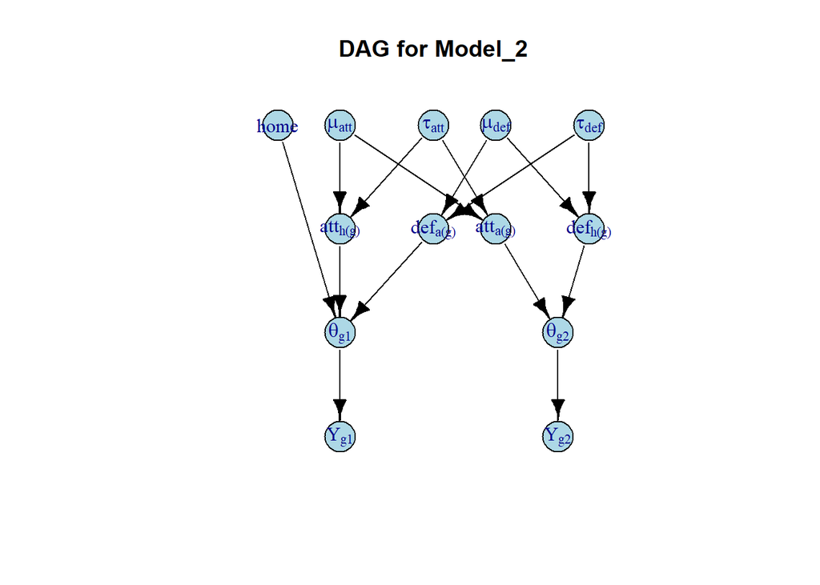

```r
graph <- make_empty_graph(directed=T)
graph <- graph + vertex(color= 'lightblue',name=expression(mu ["att"]))+ vertex(color= 'lightblue',name=expression(tau ["att"]))+ vertex(color= 'lightblue',name=expression(mu ["def"]))+ vertex(color= 'lightblue',name=expression(tau ["def"]))+ vertex(color= 'lightblue',name=expression("Y"["g1"]))+ vertex(color= 'lightblue',name=expression("Y"["g2"]))+ vertex(color= 'lightblue',name=expression(theta ["g1"]))+ vertex(color= 'lightblue',name=expression(theta ["g2"]))+ vertex(color= 'lightblue',name="home")+ vertex(color= 'lightblue',name=expression("att" ["h(g)"]))+ vertex(color= 'lightblue',name=expression("def" ["a(g)"]))+ vertex(color= 'lightblue',name=expression("att" ["a(g)"]))+vertex(color= 'lightblue',name=expression("def" ["h(g)"]))

graph <- graph + edge(7,5)+ edge(8,6)+ edge(9,7)+ edge(10,7)+ edge(11,7)+ edge(12,8)+ edge(13,8) + edge(1,10) + edge(2,10) + edge(1,12) + edge(2,12) + edge(3,11) + edge(4,13) + edge(3,13) + edge(4,11)

l <- layout_with_sugiyama(graph, layers = NULL, hgap = 1, vgap = 1,
  maxiter = 100, weights = NULL, attributes = c("default", "all", "none"))

plot(graph, layout=l$layout,edge.color='black', main="DAG for Model_2", vertex.size=20, edge.arrow.size=0.9)
```

The hierarchical nature implies a form of correlation between the observable variables $Y_{g1}$ and $Y_{g2}$ by means of the unobservable hyper-parameters $\eta = (\mu_{att}, \mu_{def} , \tau_{att}, \tau_{def} )$. In fact, the components of $\eta$ represent a **latent structure** that we assume to be common for all the games played in a season and that determines the average scoring rate.

The *Jags code* is the following one:

```r
'''
model{
  for (i in 1:number_match){
    # stochastic component
    x[i]~dpois(lambda1[i])
    y[i]~dpois(lambda2[i])
    # link and linear predictor
    log(lambda1[i])<-  home + a[ ht[i] ] + d[ at[i] ]
    log(lambda2[i])<-  a[ at[i] ] + d[ ht[i] ]
  }
  # STZ constraints
  a[1]<-  -sum( a[2:20] )
  d[1]<-  -sum( d[2:20] )
  #
  # prior distributions

  home~dnorm(0,0.001)

    tau.att ~ dgamma(0.01,0.01)
    tau.def ~ dgamma(0.01,0.01)


for (i in 1:number_teams){
    m1[i] ~ dnorm(0,100)
    m2[i] ~ dnorm(0,100)
}

  for (i in 2:number_teams){

    a[i]~dnorm(m1[i],tau.att)
    d[i]~dnorm(m2[i],tau.def)
  }

}
'''
```

Now we can we can load the second model:

```r
model_2 = jags(data = soccer.data, inits = soccer.init,
                parameters.to.save = soccer.param,
                model.file = "C:/Users/user/Desktop/Tardella/model_2.txt",
                n.chains = 2,
                n.iter = 50000,n.burnin = 25000)
```

- **number of iterations**: 50000
- **number of chains**: 2
- **burn-in**: 25000
- **n.thin**: 25

```r
mm2 <- as.mcmc(model_2)
summary(mm2)
```

```
##
## Iterations = 25001:49976
## Thinning interval = 25
## Number of chains = 2
## Sample size per chain = 1000
##
## 1. Empirical mean and standard deviation for each variable,
##    plus standard error of the mean:
##
##                Mean      SD  Naive SE Time-series SE
## a[1]      3.674e-01 0.10146 0.0022686      0.0023525
## a[10]     4.360e-01 0.09401 0.0021021      0.0022999
## a[11]     4.649e-01 0.09554 0.0021363      0.0021368
## a[12]     1.085e-01 0.11133 0.0024893      0.0024897
## a[13]    -2.490e-01 0.12973 0.0029009      0.0031409
## a[14]     2.851e-02 0.11649 0.0026048      0.0025995
## a[15]    -8.334e-02 0.12291 0.0027484      0.0030149
## a[16]     7.081e-02 0.11788 0.0026358      0.0027710
## a[17]    -4.575e-01 0.15074 0.0033707      0.0035972
## a[18]     1.775e-01 0.10721 0.0023972      0.0026143
## a[19]    -7.047e-02 0.11930 0.0026676      0.0027836
## a[2]     -1.758e-01 0.12555 0.0028075      0.0031688
## a[20]    -6.779e-02 0.12220 0.0027324      0.0029000
## a[3]     -1.279e-01 0.12381 0.0027686      0.0027873
## a[4]     -1.509e-01 0.12310 0.0027527      0.0027515
## a[5]      1.564e-01 0.11008 0.0024614      0.0026332
## a[6]      7.289e-02 0.11402 0.0025496      0.0027276
## a[7]     -1.248e-01 0.12586 0.0028143      0.0028259
## a[8]     -3.733e-01 0.13949 0.0031191      0.0035997
## a[9]     -2.055e-03 0.11975 0.0026776      0.0027507
## d[1]      1.589e-01 0.11156 0.0024946      0.0027711
## d[10]    -1.981e-01 0.12904 0.0028855      0.0030495
## d[11]    -2.519e-01 0.13384 0.0029928      0.0034525
## d[12]    -3.467e-01 0.13785 0.0030824      0.0032555
## d[13]    -8.311e-03 0.11618 0.0025979      0.0026769
## d[14]     1.935e-01 0.11031 0.0024667      0.0025263
## d[15]     1.321e-01 0.11223 0.0025095      0.0025095
## d[16]     2.714e-01 0.10417 0.0023293      0.0025155
## d[17]    -5.697e-03 0.11523 0.0025766      0.0026337
## d[18]    -1.453e-01 0.12800 0.0028621      0.0029573
```

[output cut: 43 more lines]

```
## d[16]       0.06676  2.038e-01  2.721e-01  3.418e-01  4.753e-01
## d[17]      -0.24154 -8.102e-02 -1.946e-03  7.116e-02  2.133e-01
## d[18]      -0.40678 -2.277e-01 -1.425e-01 -6.000e-02  1.047e-01
## d[19]      -0.14932  6.900e-04  7.939e-02  1.477e-01  2.867e-01
## d[2]       -0.23637 -8.174e-02 -7.062e-03  7.287e-02  2.202e-01
## d[20]       0.13805  2.698e-01  3.425e-01  4.058e-01  5.315e-01
## d[3]       -0.29856 -1.437e-01 -6.228e-02  2.323e-02  1.828e-01
## d[4]       -0.55567 -3.682e-01 -2.765e-01 -1.941e-01 -2.934e-02
## d[5]       -0.38154 -2.168e-01 -1.315e-01 -4.781e-02  1.077e-01
## d[6]       -0.07721  5.279e-02  1.292e-01  2.044e-01  3.417e-01
## d[7]       -0.22189 -6.543e-02  1.560e-02  8.633e-02  2.336e-01
## d[8]       -0.08005  7.182e-02  1.451e-01  2.144e-01  3.633e-01
## d[9]       -0.26248 -9.485e-02 -1.170e-02  6.940e-02  2.133e-01
## deviance 2686.70364  2.695e+03  2.700e+03  2.706e+03  2.720e+03
## home        0.77867  8.250e-01  8.490e-01  8.725e-01  9.149e-01
```

Now we can take a look about the parameters:

```r
off_att <- model_2$BUGSoutput$mean$a
super_def <- model_2$BUGSoutput$mean$d
home_sweet <- model_2$BUGSoutput$mean$home

XY <- data.frame(cbind(levels(Serie_A$HomeTeam),off_att,super_def,home_sweet))
colnames(XY)<- c("Team","Attack","Defense","Home")

kable(XY)
```

| Team | Attack | Defense | Home |
| --- | --- | --- | --- |
| Atalanta | 0.367372138055527 | 0.158883309870275 | 0.84841381601054 |
| Benevento | -0.175821815239249 | -0.00673382823091778 | 0.84841381601054 |
| Bologna | -0.127863211006973 | -0.0613901198226534 | 0.84841381601054 |
| Cagliari | -0.150883460374781 | -0.280749829565293 | 0.84841381601054 |
| Chievo | 0.156370976008515 | -0.131929887795444 | 0.84841381601054 |
| Crotone | 0.0728932119315309 | 0.129661600377758 | 0.84841381601054 |
| Fiorentina | -0.124847221995309 | 0.0107471196398938 | 0.84841381601054 |
| Genoa | -0.373291105153904 | 0.142478134455909 | 0.84841381601054 |
| Inter | -0.00205490857632852 | -0.0149343585441771 | 0.84841381601054 |
| Juventus | 0.435965549274734 | -0.198079520785216 | 0.84841381601054 |
| Lazio | 0.464914286828455 | -0.251896771458623 | 0.84841381601054 |
| Milan | 0.108511456028971 | -0.346653909541855 | 0.84841381601054 |
| Napoli | -0.248982043961836 | -0.00831100097842098 | 0.84841381601054 |
| Roma | 0.0285127439945175 | 0.193504881684857 | 0.84841381601054 |
| Sampdoria | -0.0833421314481405 | 0.132078320339913 | 0.84841381601054 |
| Sassuolo | 0.0708094225613635 | 0.27140300631731 | 0.84841381601054 |
| Spal | -0.457544674962445 | -0.00569725490516547 | 0.84841381601054 |
| Torino | 0.177545243506273 | -0.145276980368452 | 0.84841381601054 |
| Udinese | -0.0704720175098258 | 0.0743381495377984 | 0.84841381601054 |
| Verona | -0.067792437961095 | 0.338558939772504 | 0.84841381601054 |

Now **it’s time to make the diagnostic** also in this model, looking at the same plot explained before:

### Traceplot

[figure not shown]

[figure not shown]

[figure not shown]

[figure not shown]

[figure not shown]

[figure not shown]

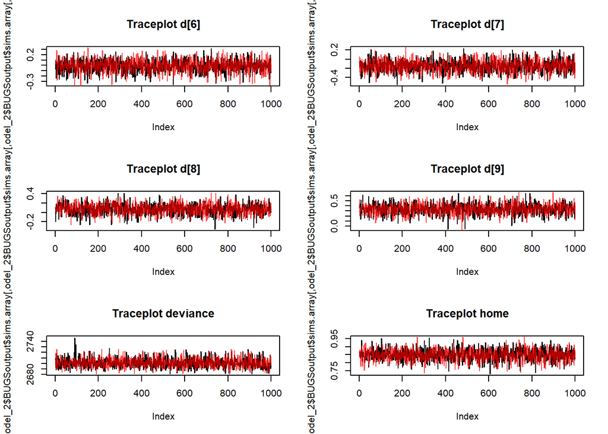

```r
par(mfrow=c(3,2))
par_list <- colnames(mm2[[1]])
for (i in 1:dim(model_1$BUGSoutput$sims.array)[3])
{
  plot(model_2$BUGSoutput$sims.array[,1,i], type = "l", main=paste("Traceplot",par_list[i]))
  points(model_2$BUGSoutput$sims.array[,2,i], type = "l", col=rgb(1,0,0,0.7))
}
```

```r
par(mfrow=c(1,1))
```

### Autocorrelation

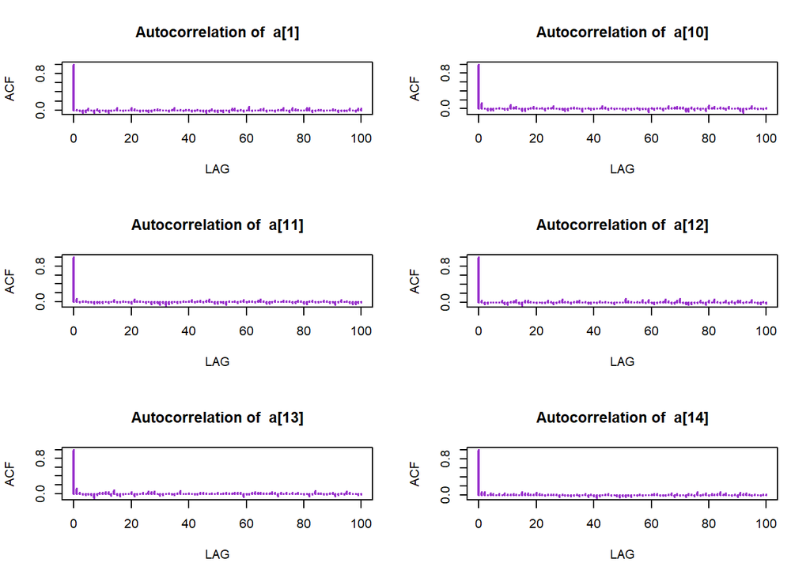

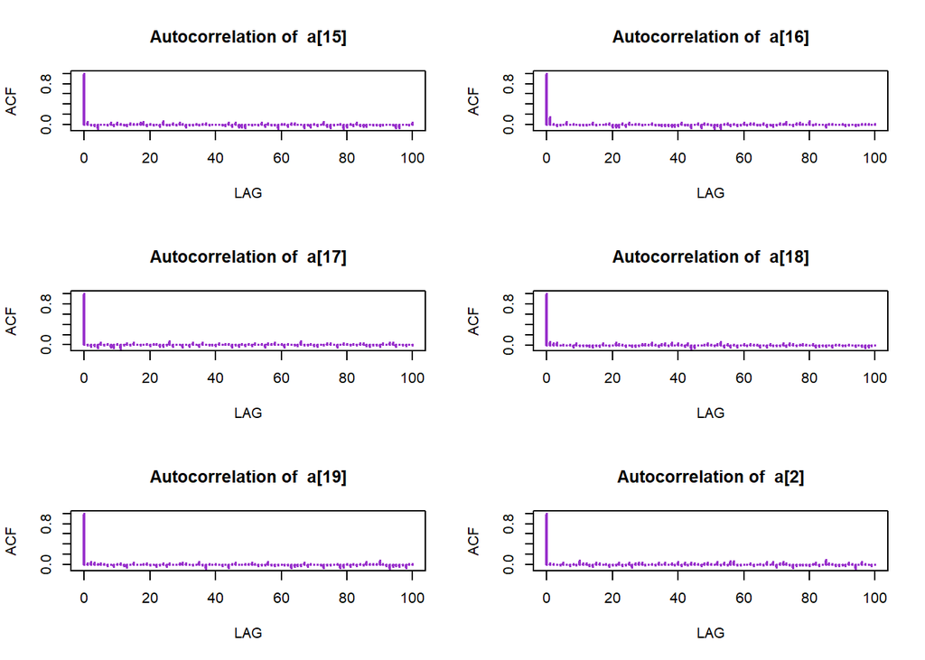

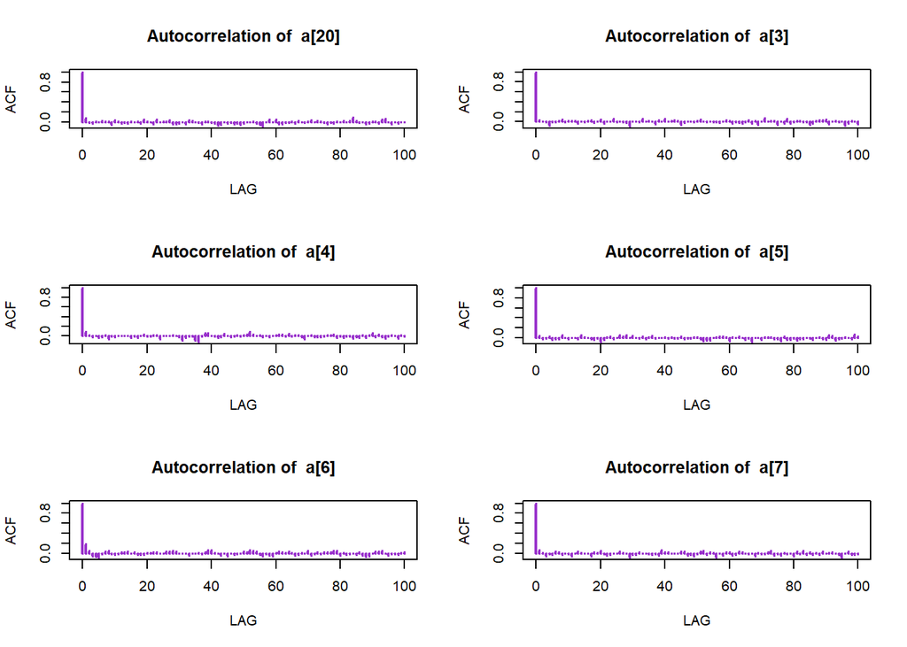

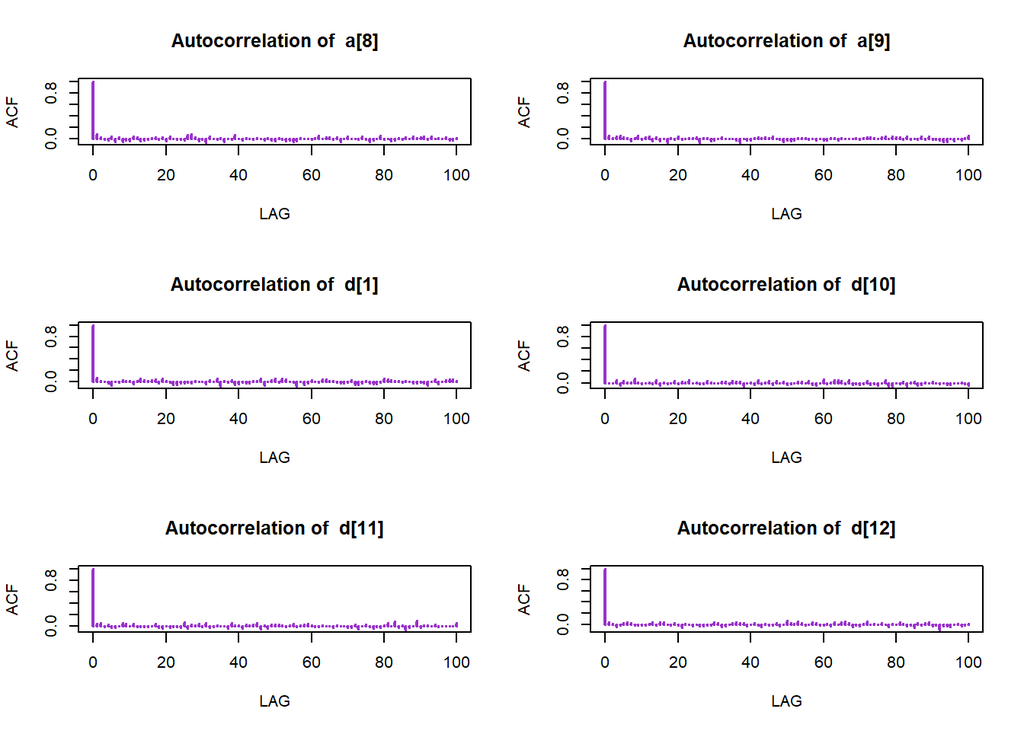

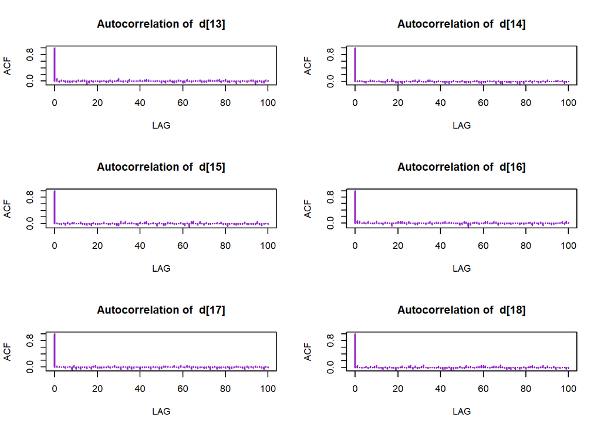

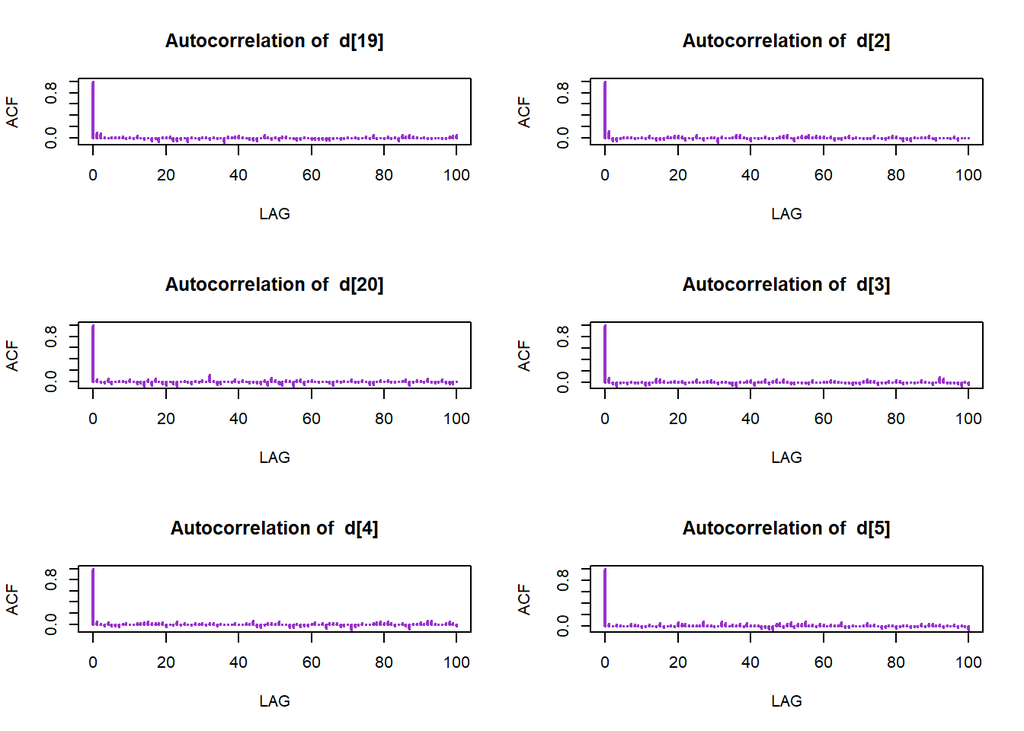

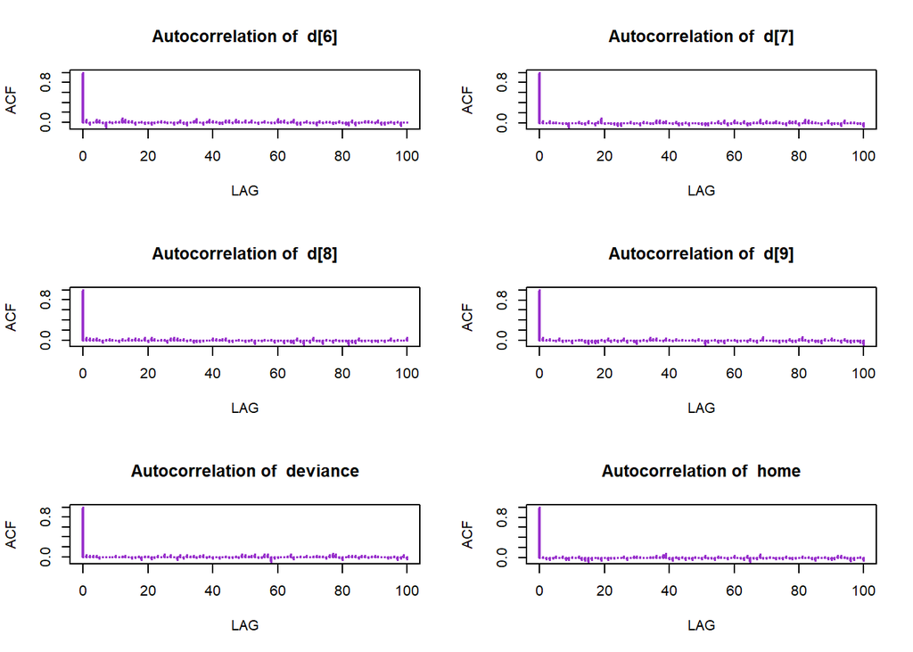

```r
par(mfrow=c(3,2))
for(i in 1:dim(model_2$BUGSoutput$sims.array)[3])
{
  acf_main <- acf(model_2$BUGSoutput$sims.array[,1,i], plot = F, lag.max=100)
  plot(acf_main$lag, acf_main$acf, type='h', col = 'darkorchid',  xlab="LAG", ylab="ACF", lwd=2, main=paste("Autocorrelation of ",par_list[i]))
}
```

```r
par(mfrow=c(1,1))
```

### Density Plot

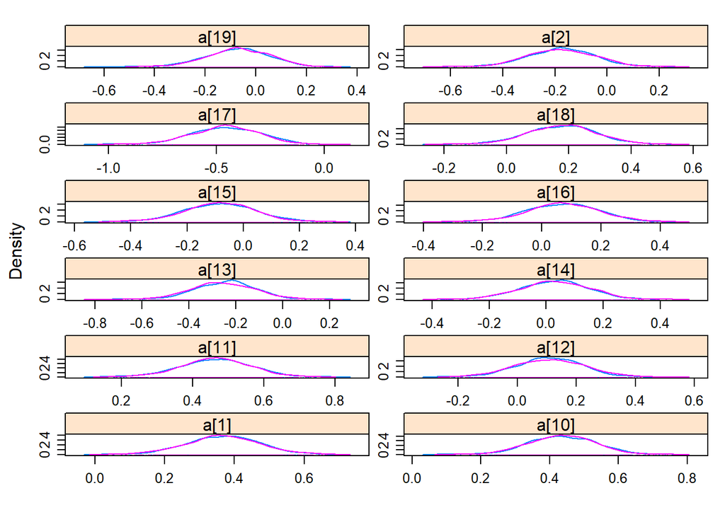

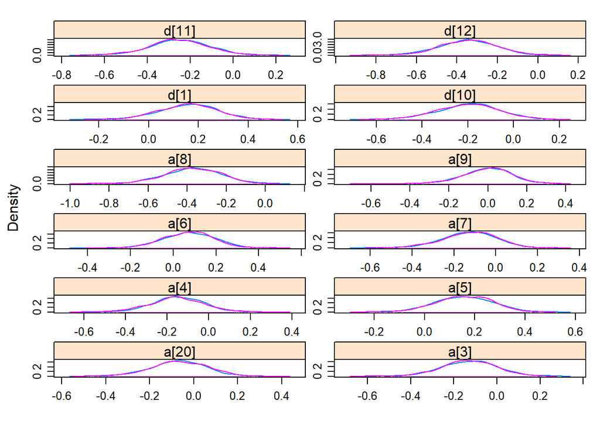

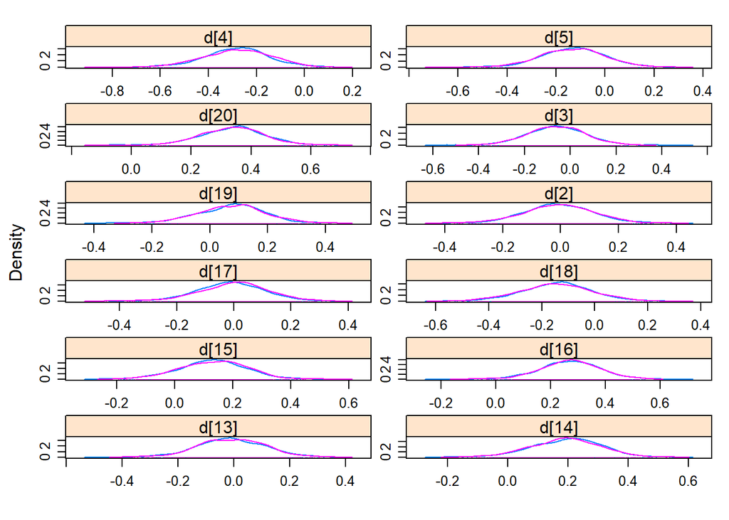

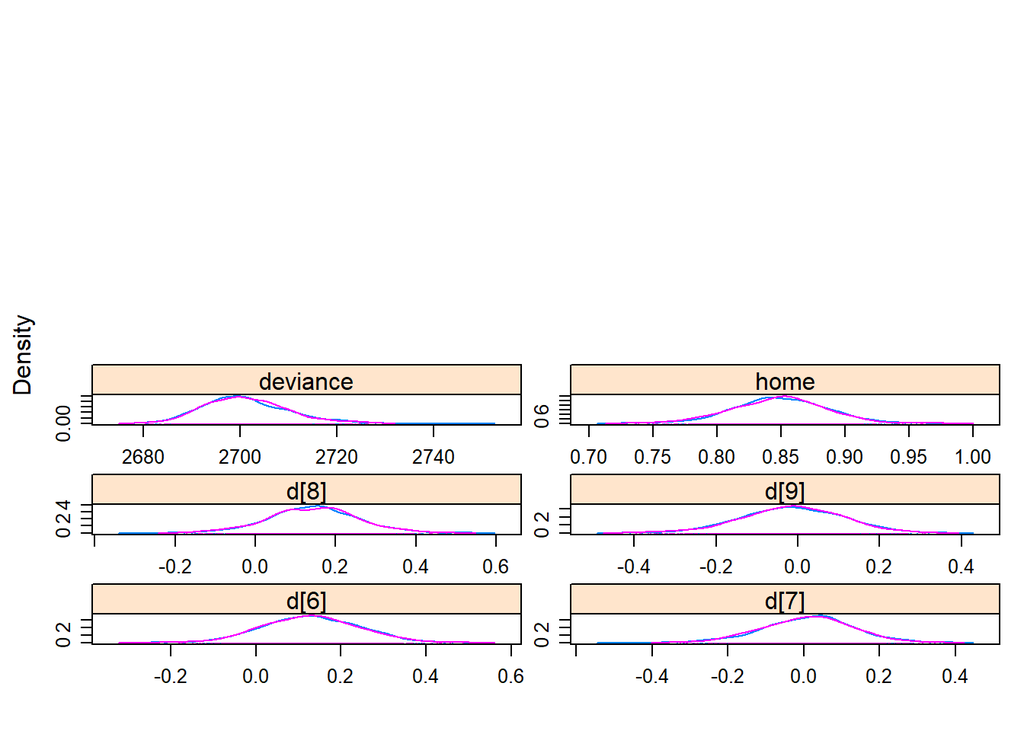

```r
par(mfrow=c(3,1))
densityplot(as.mcmc(model_2),layout=c(2,6),aspect="fill" )
```

```r
par(mfrow=c(1,1))
```

### Gelman-Rubin Plot

```r
mm2 = as.mcmc(model_2)
colnames(mm2[[1]])
```

```
##  [1] "a[1]"     "a[10]"    "a[11]"    "a[12]"    "a[13]"    "a[14]"
##  [7] "a[15]"    "a[16]"    "a[17]"    "a[18]"    "a[19]"    "a[2]"
## [13] "a[20]"    "a[3]"     "a[4]"     "a[5]"     "a[6]"     "a[7]"
## [19] "a[8]"     "a[9]"     "d[1]"     "d[10]"    "d[11]"    "d[12]"
## [25] "d[13]"    "d[14]"    "d[15]"    "d[16]"    "d[17]"    "d[18]"
## [31] "d[19]"    "d[2]"     "d[20]"    "d[3]"     "d[4]"     "d[5]"
## [37] "d[6]"     "d[7]"     "d[8]"     "d[9]"     "deviance" "home"
```

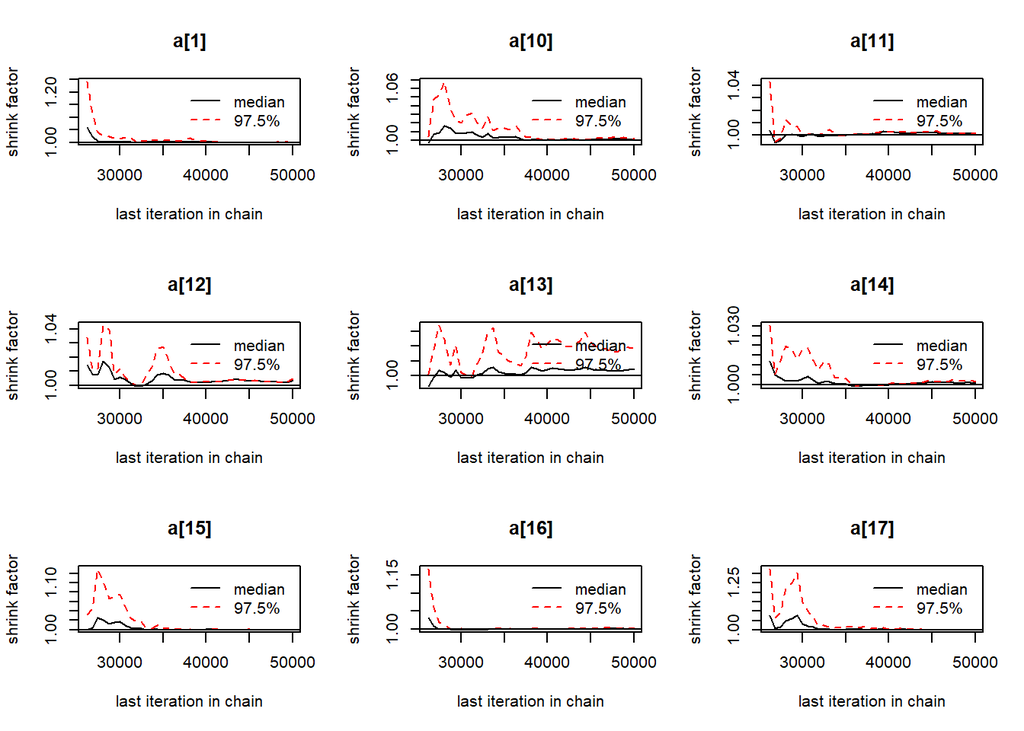

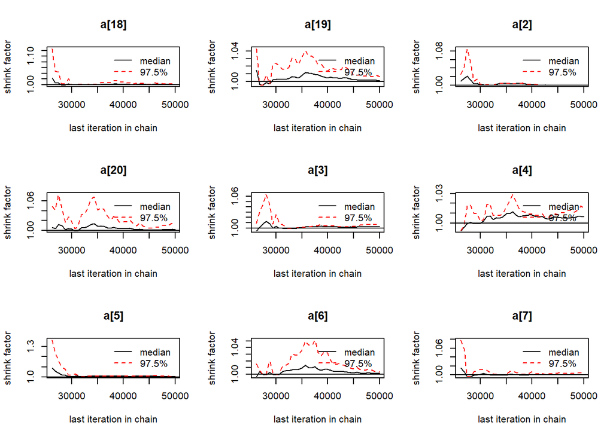

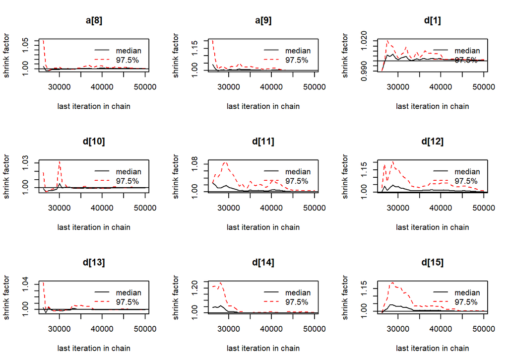

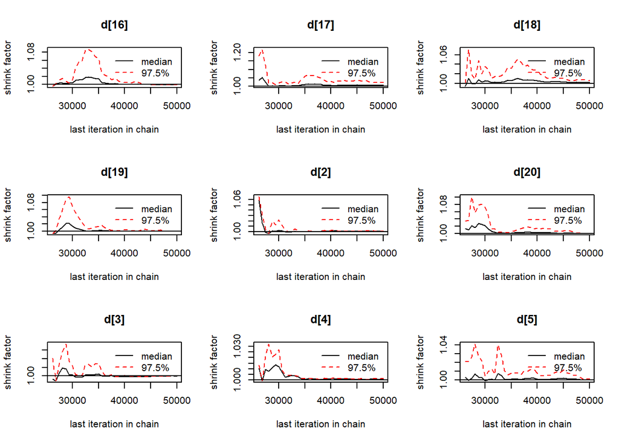

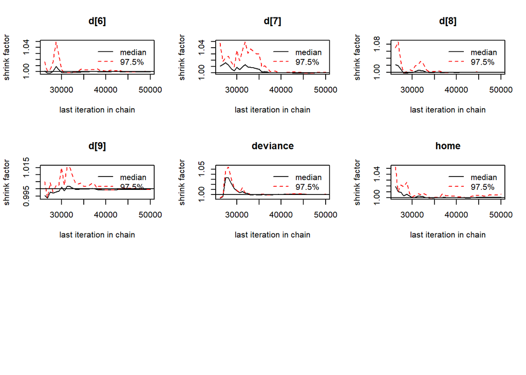

```r
gelman.plot(mm2)
```

### Geweke-Broks Plot

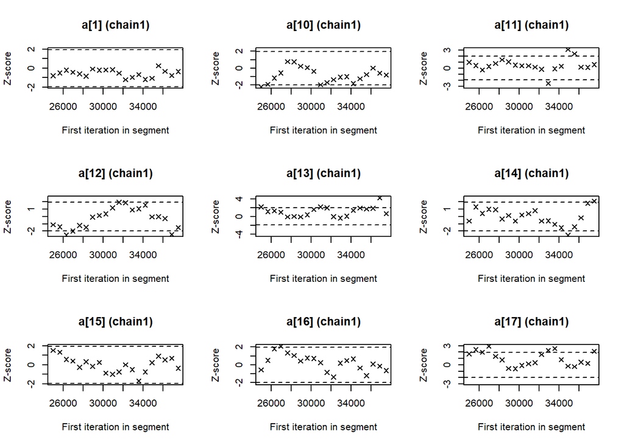

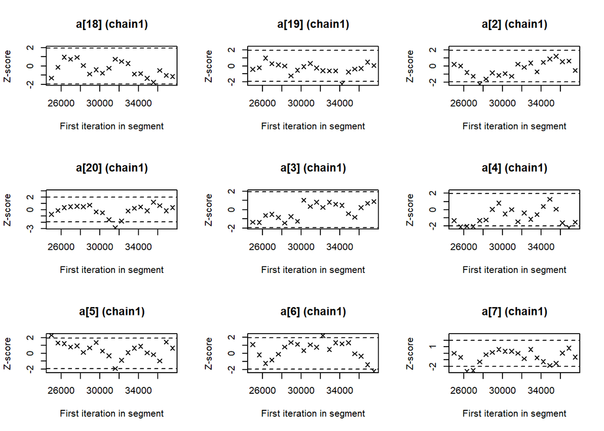

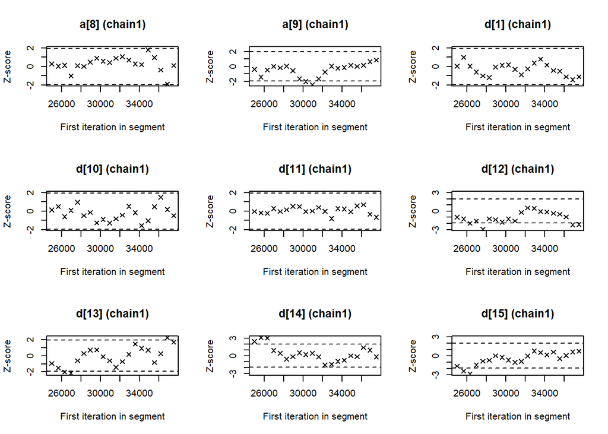

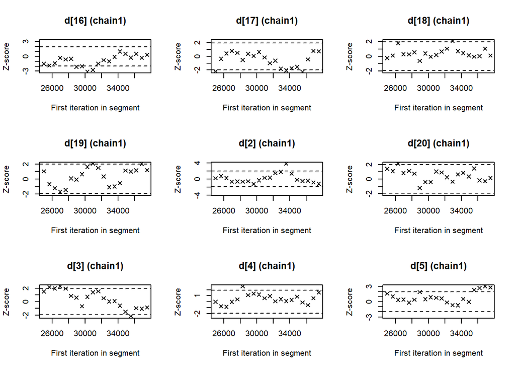

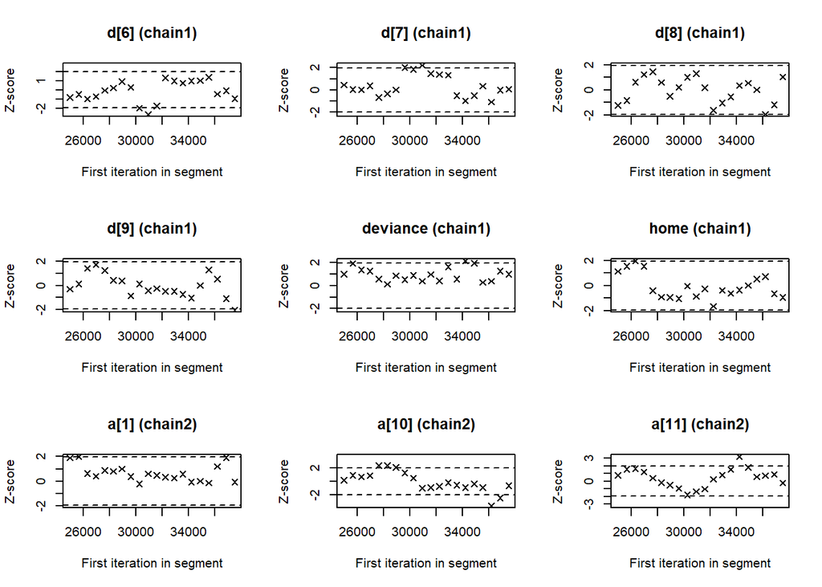

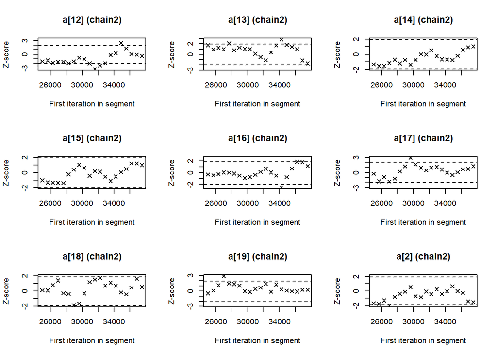

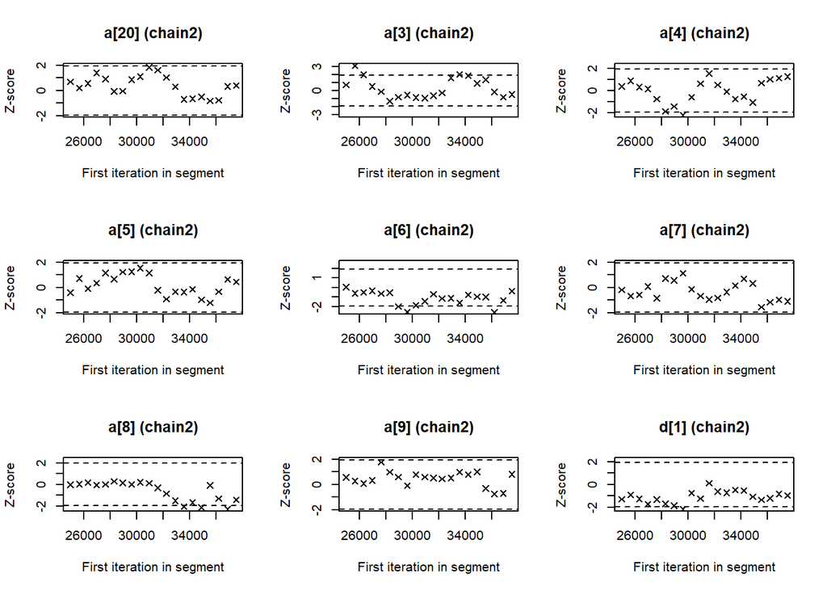

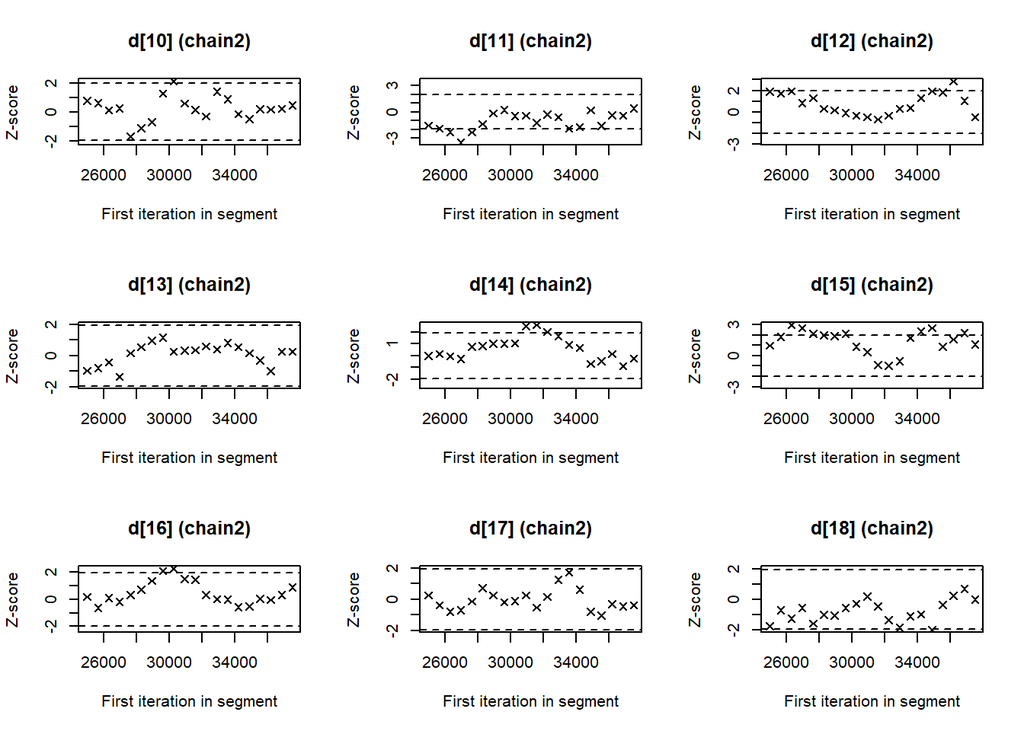

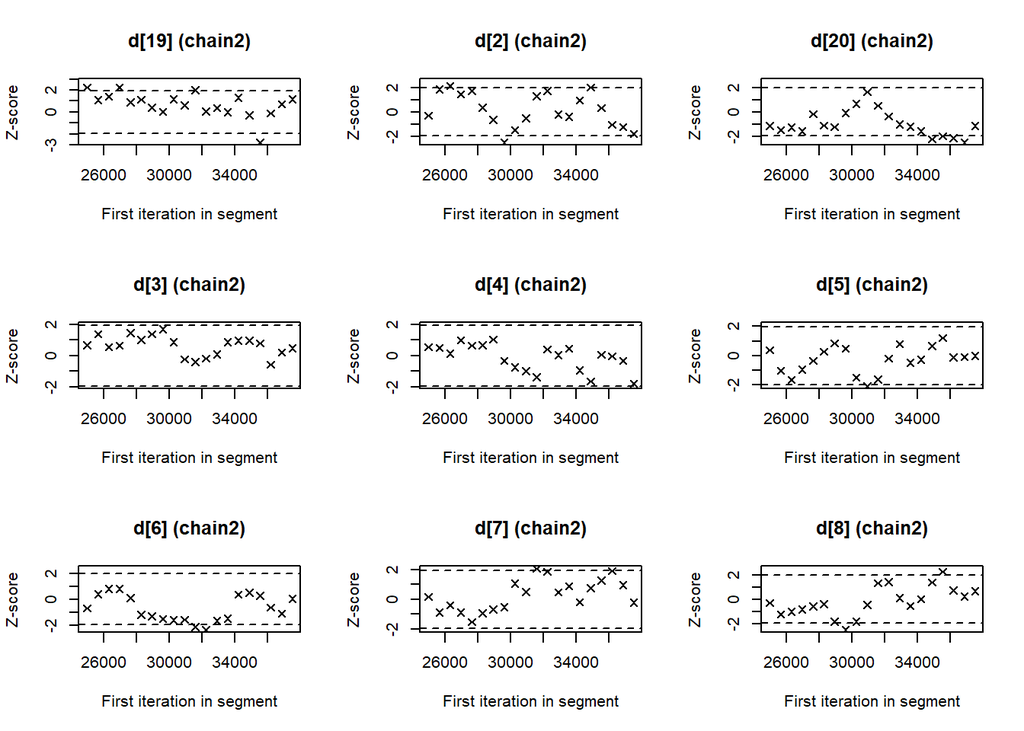

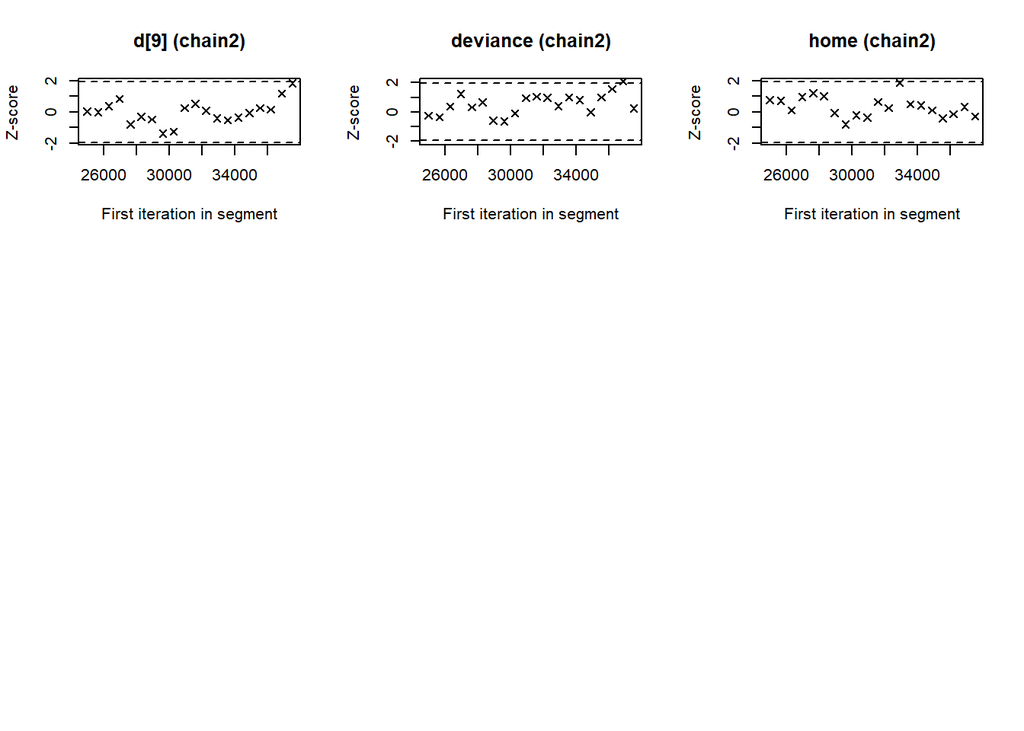

```r
geweke.plot(mm2)
```

# Models comparison

In order to compare the two models is needed an index known as **DIC**, which is a *penalized fit criterion* applicable to compare models. The **DIC** (Deviance Information Criterion) is a Bayesian criterion for model comparison, it is defined as:

$$DIC =\bar{D}+d_e=D(\bar{\theta}) + 2d_e$$

where:

- $D(\theta) = -2log(L(\theta))$
- $d_e = \bar{D} - D(\bar{\theta})$. It is the effective number of parameters of the model. The largest $d_e$ is, the easier it is for the model to fit the data.
- $\bar{D}= \mathbb{E}_0[D(\theta)]$. It is a measure of how well the model fit the data; the larger this is, the worse the fit.
- $D(\bar{\theta})=D(\mathbb{E}(\theta))$

The idea is that the models with smaller DIC should be preferred to models with larger DIC. Models are penalized both by the value of $\bar{D}$, which favors a good fit, but also by $d_e$. Since $\bar{D}$ will decrease as the number of parameters increases in the model, the $d_e$ term compensates for this effect by favoring models with a smaller number of parameters. The DIC is easily computed from samples generated by a Markov Chain Monte Carlo simulation.

Now **lets evaluate the DIC** for the two models just specified:

```r
c("First model" = model_1$BUGSoutput$DIC, "Second model" = model_2$BUGSoutput$DIC)
```

```
##  First model Second model
##     2519.470     2735.981
```

However, **this value compares two different models, but in our case more than two models we are analyzing the same model with changes in the prior**s, so the value returned by the *DIC doesn’t have much meaning*.

# Frequentist analysis

Let’s move to a frequentist approach. To model the goals we use a **Generalized Linear Model**, that is a flexible generalization of ordinary linear regression that allows for response variables that have error distribution models other than a normal distribution. The GLM generalizes linear regression by allowing the linear model to be related to the response variable via a link function.

In the GLM model we set the family argument to Poisson since we’re modeling low and non negative numbers *(counts)*. Regarding the **link function**, we use the log. In fact we know that the $\lambda$ parameter of a Poisson, which represents the distribution of the goals making by each team, must be a value in the interval $[0,+\infty)$.

Knowing that each value of the $Y$ variable is distributed as a **Poisson**. The expected value depends on the independent variable $X$, which in our case represents the features about the team we are analyzing:

$E(Y)=\lambda=g^{-1}(X\beta)$

$X\beta$ it is the linear predictor, a linear combination of unknown parameters $\beta$,which represent the values of attack and defense of opposing teams; $g$ is the **link function**.

At this point we have to choose a link function that allows to respect the parameter support $\lambda$, so that the values that will give us back the linear combination of the estimators are mapped in the same domain.

For this reason $g$ it’s a logarithmic function that allows our prediction to obtain values between $(-\infty,+\infty)$ just like the codomain of the function $g(\lambda)$.

### Frequentist Model

```r
#Frequentist Model

Frequentist_model <-rbind(data.frame(goals=new_data$FTHG,team=Serie_A$HomeTeam,opponent=Serie_A$AwayTeam,home=1),data.frame(goals=new_data$FTAG,team=Serie_A$AwayTeam,opponent=Serie_A$HomeTeam,home=0)) %>%
glm(goals ~ home + team +opponent, family=poisson(link=log),data=.)

summary(Frequentist_model)
```

```
##
## Call:
## glm(formula = goals ~ home + team + opponent, family = poisson(link = log),
##     data = .)
##
## Deviance Residuals:
##     Min       1Q   Median       3Q      Max
## -2.4217  -1.0819  -0.1082   0.5662   2.7556
##
## Coefficients:
##                    Estimate Std. Error z value Pr(>|z|)
## (Intercept)         0.04622    0.21317   0.217 0.828338
## home                0.17547    0.06296   2.787 0.005316 **
## teamBenevento      -0.50102    0.21904  -2.287 0.022177 *
## teamBologna        -0.34157    0.20650  -1.654 0.098103 .
## teamCagliari       -0.52508    0.21898  -2.398 0.016493 *
## teamChievo         -0.43994    0.21313  -2.064 0.039003 *
## teamCrotone        -0.32703    0.20653  -1.583 0.113330
## teamFiorentina     -0.04694    0.19014  -0.247 0.805003
## teamGenoa          -0.54348    0.21893  -2.482 0.013051 *
## teamInter           0.13762    0.18102   0.760 0.447105
## teamJuventus        0.39665    0.17100   2.320 0.020361 *
## teamLazio           0.45777    0.16994   2.694 0.007065 **
## teamMilan          -0.01463    0.18838  -0.078 0.938080
## teamNapoli          0.29108    0.17494   1.664 0.096133 .
## teamRoma            0.05663    0.18441   0.307 0.758796
## teamSampdoria       0.00424    0.18844   0.022 0.982050
## teamSassuolo       -0.65660    0.22832  -2.876 0.004030 **
## teamSpal           -0.35971    0.20806  -1.729 0.083835 .
## teamTorino         -0.04694    0.19014  -0.247 0.805003
## teamUdinese        -0.14729    0.19618  -0.751 0.452790
## teamVerona         -0.60293    0.22583  -2.670 0.007590 **
## opponentBenevento   0.74432    0.19402   3.836 0.000125 ***
## opponentBologna     0.27080    0.21207   1.277 0.201638
## opponentCagliari    0.42355    0.20525   2.064 0.039061 *
## opponentChievo      0.39324    0.20661   1.903 0.057004 .
## opponentCrotone     0.50981    0.20223   2.521 0.011704 *
## opponentFiorentina  0.16238    0.21794   0.745 0.456224
## opponentGenoa       0.07326    0.22134   0.331 0.740655
## opponentInter      -0.25364    0.24311  -1.043 0.296808
## opponentJuventus   -0.45643    0.25973  -1.757 0.078857 .
## opponentLazio       0.26303    0.21497   1.224 0.221127
## opponentMilan       0.07325    0.22265   0.329 0.742147
## opponentNapoli     -0.27618    0.24549  -1.125 0.260588
## opponentRoma       -0.32792    0.24795  -1.323 0.185992
## opponentSampdoria   0.43103    0.20599   2.093 0.036393 *
## opponentSassuolo    0.38604    0.20659   1.869 0.061681 .
## opponentSpal        0.39635    0.20662   1.918 0.055081 .
## opponentTorino      0.16238    0.21794   0.745 0.456225
## opponentUdinese     0.47154    0.20403   2.311 0.020824 *
## opponentVerona      0.66685    0.19635   3.396 0.000683 ***
## ---
## Signif. codes:  0 '***' 0.001 '**' 0.01 '*' 0.05 '.' 0.1 ' ' 1
##
## (Dispersion parameter for poisson family taken to be 1)
##
##     Null deviance: 995.37  on 759  degrees of freedom
## Residual deviance: 774.00  on 720  degrees of freedom
## AIC: 2172
##
## Number of Fisher Scoring iterations: 5
```

Observing the values of the coefficients, the differences between the teams with the best attacks and the teams with the best defenses are respected, the same for the teams with the two worst characteristics according to what we have obtained before in the 2 Bayesian Model. However, **we note a broad decrease in the home factor**.

In fact, if in the first two models we obtained values of 0.23 and 0.83 now in the frequentist model, it assumes a coefficient of 0.17, probably in the frequentist model the teams playing at home are not affected by the same positive effect analyzed in the Bayesian models.

Now, we can make a small example about a single match, in this specific case we are analyzing *the capital Derby* between **Lazio** and **Rome**. Firstly we see the result when Rome hosts Lazio.

```r
#Roma - Lazio
predict(Frequentist_model, data.frame(home=1, team="Roma", opponent="Lazio"), type="response")
```

```
##        1
## 1.718325
```

While we can observe the inverse of the previous case, when Rome has to play away… but always in the same Stadium for this specific case.

```r
#Lazio-Roma
predict(Frequentist_model, data.frame(home=0, team="Roma", opponent="Lazio"), type="response")
```

```
##        1
## 1.441777
```

Observing the results we have obtained, we see how the first $\lambda$ parameter reflects Rome’s offensive ability to score when it plays at home, while outside the home $\lambda$’s value decreases but only slightly.

Here we have created a function that can **simulate the possible results** of a match using the $\lambda$ parameter returned by the frequentist model, observing the possibility of scoring a specific quantity of goals with that specific lambda, using the likelihood.

```r
#Function for the simulation of a match
simulate_match <- function(modello, homeTeam, awayTeam, max_goals=10)
  {
    home_goals_avg <- predict(modello,data.frame(home=1, team=homeTeam, opponent=awayTeam), type="response")
    away_goals_avg <- predict(modello, data.frame(home=0, team=awayTeam, opponent=homeTeam), type="response")
    dpois(0:max_goals, home_goals_avg) %o% dpois(0:max_goals, away_goals_avg)
  }
#Derby Simulation
derby <- simulate_match(Frequentist_model, "Roma", "Lazio", max_goals=6)
#Matrix of probability
derby
```

```
##             [,1]        [,2]        [,3]         [,4]         [,5]
## [1,] 0.054429210 0.064908433 0.038702607 0.0153846651 0.0045866663
## [2,] 0.093527069 0.111533778 0.066503654 0.0264358537 0.0078813831
## [3,] 0.080354947 0.095825636 0.057137443 0.0227126932 0.0067713885
## [4,] 0.046025303 0.054886526 0.032726898 0.0130092623 0.0038784819
## [5,] 0.019771606 0.023578222 0.014058861 0.0055885350 0.0016661230
## [6,] 0.006794809 0.008103009 0.004831538 0.0019205838 0.0005725881
## [7,] 0.001945948 0.002320600 0.001383692 0.0005500312 0.0001639821
##              [,6]         [,7]
## [1,] 1.093947e-03 2.174273e-04
## [2,] 1.879756e-03 3.736107e-04
## [3,] 1.615016e-03 3.209923e-04
## [4,] 9.250407e-04 1.838564e-04
## [5,] 3.973801e-04 7.898125e-05
## [6,] 1.365656e-04 2.714309e-05
## [7,] 3.911069e-05 7.773441e-06
```

The result we obtain is a matrix, in which the probability that the game can end with a given result. Obviously if we sum up the values on the **diagonal** we will have the probability that the match will end in a **draw** while if we add the **upper diagonal** we get the probability of victory of **Lazio** while the **lower diagonal** of **Rome**.

We can conclude by looking at the results we get:

```r
#Observing the result
c("Roma winning",sum(derby[lower.tri(derby)]))
```

```
## [1] "Roma winning"      "0.494969496900574"
```

```r
c("Draw",sum(diag(derby)))
```

```
## [1] "Draw"              "0.237920156005423"
```

```r
c("Lazio winning",sum(derby[upper.tri(derby)]))
```

```
## [1] "Lazio winning"     "0.264878975531555"
```

## Prediction on the second half of the Championship

We try to predict the results of the second half of the season by comparing the 3 models we have described so far.

#### Bayesian Model_1

```r
# INITS
soccer.init = list(list("home" = 0.7, "a" = c(NA,rep(0.2, team-1)), "d" = c(NA,rep(0.2, team-1))),list("home" = 0.7, "a" = c(NA,rep(0.2, team-1)), "d" = c(NA,rep(0.2, team-1))))

# PARAMETERS OF INTEREST
#soccer.param = c("a", "d", "home")
soccer.param = c("a", "d", "home", "x", "y")

soccer.data = list(x = c(new_data$FTHG[1:190],rep(NA,190)), y = c(new_data$FTAG[1:190],rep(NA,190)), number_match = match, number_teams = team, ht = new_data$HomeTeam, at = new_data$AwayTeam)
```

Train the first model:

```r
model_pred_1 = jags(data = soccer.data, inits = soccer.init, parameters.to.save = soccer.param, model.file = "C:/Users/user/Desktop/Tardella/model_1.txt", n.chains = 2, n.iter = 10000)
```

Evaluating the model for the second part of the League

```r
# Distribution of the HomeTeam in the last part Of the League
pred_distro_home <- as.data.frame(model_pred_1$BUGSoutput$sims.list$x[,191:380])
pred_distro_away <- as.data.frame(model_pred_1$BUGSoutput$sims.list$y[,191:380])

gol_home_m1 <- NULL
gol_away_m1 <- NULL
for(i in 1:ncol(pred_distro_away))
{
  gol_home_m1[i] <- round(mean(pred_distro_home[,i]))
  gol_away_m1[i] <- round(mean(pred_distro_away[,i]))
}

#gol_home_m1
#gol_away_m1
```

#### Bayesian Model_2

```r
# INITS
soccer.init = list(list("home" = 0.7, "a" = c(NA,rep(0.2, team-1)), "d" = c(NA,rep(0.2, team-1))),list("home" = 0.7, "a" = c(NA,rep(0.2, team-1)), "d" = c(NA,rep(0.2, team-1))))

# PARAMETERS OF INTEREST
#soccer.param = c("a", "d", "home")
soccer.param = c("a", "d", "home", "x", "y")

soccer.data = list(x = c(new_data$FTHG[1:190],rep(NA,190)), y = c(new_data$FTAG[1:190],rep(NA,190)), number_match = match, number_teams = team, ht = new_data$HomeTeam, at = new_data$AwayTeam)
```

Train the second model:

```r
model_pred_2 = jags(data = soccer.data, inits = soccer.init, parameters.to.save = soccer.param, model.file = "C:/Users/user/Desktop/Tardella/model_2.txt", n.chains = 2, n.iter = 10000)
```

Evaluating the second model

```r
# Distribution of the second part of the League
pred_distro_home <- as.data.frame(model_pred_2$BUGSoutput$sims.list$x[,191:380])
pred_distro_away <- as.data.frame(model_pred_2$BUGSoutput$sims.list$y[,191:380])

gol_home_m2 <- NULL
gol_away_m2 <- NULL
for(i in 1:ncol(pred_distro_away))
{
  gol_home_m2[i] <- round(mean(pred_distro_home[,i]))
  gol_away_m2[i] <- round(mean(pred_distro_away[,i]))
}

#gol_home_m2
#gol_away_m2
```

#### Frequentist Model

Training the frequentist model on the first part of the League :

```r
Frequentist_model_3 <-rbind(data.frame(goals=new_data$FTHG[1:190],team=Serie_A$HomeTeam[1:190],opponent=Serie_A$AwayTeam[1:190],home=1),data.frame(goals=new_data$FTAG[1:190],team=Serie_A$AwayTeam[1:190],opponent=Serie_A$HomeTeam[1:190],home=0)) %>%
glm(goals ~ home + team +opponent, family=poisson(link=log),data=.)

summary(Frequentist_model_3)
```

```
##
## Call:
## glm(formula = goals ~ home + team + opponent, family = poisson(link = log),
##     data = .)
##
## Deviance Residuals:
##      Min        1Q    Median        3Q       Max
## -2.52635  -1.04431  -0.09314   0.52257   2.12270
##
## Coefficients:
##                    Estimate Std. Error z value Pr(>|z|)
## (Intercept)         0.30434    0.28248   1.077  0.28132
## home                0.13791    0.08902   1.549  0.12132
## teamBenevento      -1.02496    0.36717  -2.792  0.00525 **
## teamBologna        -0.21782    0.27972  -0.779  0.43616
## teamCagliari       -0.46185    0.30048  -1.537  0.12429
## teamChievo         -0.40710    0.29138  -1.397  0.16237
## teamCrotone        -0.77506    0.33420  -2.319  0.02039 *
## teamFiorentina     -0.02449    0.26328  -0.093  0.92588
## teamGenoa          -0.64683    0.31861  -2.030  0.04234 *
## teamInter           0.13839    0.25171   0.550  0.58246
## teamJuventus        0.49178    0.23561   2.087  0.03686 *
## teamLazio           0.46972    0.24129   1.947  0.05157 .
## teamMilan          -0.16799    0.27660  -0.607  0.54363
## teamNapoli          0.36452    0.24209   1.506  0.13213
## teamRoma            0.03395    0.26314   0.129  0.89735
## teamSampdoria       0.19734    0.25341   0.779  0.43614
## teamSassuolo       -0.78439    0.33420  -2.347  0.01892 *
## teamSpal           -0.39789    0.29565  -1.346  0.17836
## teamTorino         -0.12940    0.27352  -0.473  0.63615
## teamUdinese         0.13112    0.25553   0.513  0.60787
## teamVerona         -0.43556    0.30069  -1.449  0.14747
## opponentBenevento   0.46161    0.25413   1.816  0.06930 .
## opponentBologna     0.08505    0.27829   0.306  0.75989
## opponentCagliari    0.14521    0.27137   0.535  0.59258
## opponentChievo      0.17280    0.26753   0.646  0.51833
## opponentCrotone     0.36155    0.25930   1.394  0.16322
## opponentFiorentina -0.23917    0.29656  -0.806  0.41996
## opponentGenoa      -0.14563    0.29272  -0.498  0.61882
## opponentInter      -0.55170    0.32716  -1.686  0.09173 .
## opponentJuventus   -0.46943    0.32710  -1.435  0.15125
## opponentLazio      -0.03051    0.29330  -0.104  0.91714
## opponentMilan       0.06754    0.27797   0.243  0.80802
## opponentNapoli     -0.62641    0.34242  -1.829  0.06734 .
## opponentRoma       -0.64668    0.35192  -1.838  0.06612 .
## opponentSampdoria   0.11516    0.28086   0.410  0.68179
## opponentSassuolo    0.11183    0.27328   0.409  0.68239
## opponentSpal        0.24844    0.26563   0.935  0.34964
## opponentTorino      0.06401    0.27800   0.230  0.81789
## opponentUdinese     0.15218    0.27868   0.546  0.58501
## opponentVerona      0.44076    0.25689   1.716  0.08620 .
## ---
## Signif. codes:  0 '***' 0.001 '**' 0.01 '*' 0.05 '.' 0.1 ' ' 1
##
## (Dispersion parameter for poisson family taken to be 1)
##
##     Null deviance: 492.84  on 379  degrees of freedom
## Residual deviance: 356.72  on 340  degrees of freedom
## AIC: 1105.6
##
## Number of Fisher Scoring iterations: 5
```

Making the **prediction for the second part of the League**.

```r
Casa <- NULL
FuoriCasa <-NULL
Paregg <- NULL

for (i in 1:190){
  #print(as.character(Serie_A$HomeTeam[i]))
  a<-simulate_match(Frequentist_model_3,as.character(Serie_A$HomeTeam[i+190]),as.character(Serie_A$AwayTeam[i+190]),max_goals=8)
 Casa[i] <- sum(a[lower.tri(a)])
Paregg[i] <- sum(diag(a))
FuoriCasa[i] <- sum(a[upper.tri(a)])
}
```

### Comparison about the 3 Models

Now we can see how the 3 models predict the values about the second part of the season.

```r
esatto_1 <- 0
esatto_2 <- 0
esatto_3 <- 0
for (i in 1:190){
  #Model 1
  #print(i)
  result_1 <- cbind(gol_home_m1,gol_away_m1)
  if (result_1[i,1] == result_1[i,2] & new_data[i+190,3]==new_data[i+190,4]){
    esatto_1 = esatto_1+1
  }
  else if (which.max(result_1[i,]) == which.max(new_data[i+190,3:4])){
    esatto_1 = esatto_1+1
  }

  #Model 2
  #print(i)
  result_2 <- cbind(gol_home_m2,gol_away_m2)
  if (result_2[i,1] == result_2[i,2] & new_data[i+190,3]==new_data[i+190,4]){
    esatto_2 = esatto_2+1
  }
  else if (which.max(result_2[i,]) == which.max(new_data[i+190,3:4])){
    esatto_2 = esatto_2+1
  }
  #Frequentist Model
  frequentist <- cbind(Casa,FuoriCasa,Paregg)
  if (new_data[i+190,3]==new_data[i+190,4]){
    if(which.max(frequentist[i,])==3){
      esatto_3 <- esatto_3 +1
    }
  }
  else if(which.max(frequentist[i,])== which.max(new_data[i+190,3:4])){
    esatto_3 <- esatto_3 +1
   }
}

#Results

c("Bayesian Model_1"= esatto_1/i)
```

```
## Bayesian Model_1
##        0.6842105
```

```r
c("Bayesian Model_2"= esatto_2/i)
```

```
## Bayesian Model_2
##        0.6947368
```

```r
c("Frequentist Model_3"= esatto_3/i)
```

```
## Frequentist Model_3
##           0.5578947
```

## Betting Strategy

The expected value of the net profit for a **Unit Bet** on an Event A is given by:

$$EV(A)=P(A)Q(A) - 1$$

where event $A$ represents the victory, the draw or the defeat of the home team,$P(A)$ is the probability assigned by our model to event $A$ and $Q(A)$ is the amount that the bookmaker is willing to pay in case of realization of the event. Suppose it is a unit of our bet for this we subtract 1.

In this case we choose a rather conservative strategy as reducing the number of games to bet on, trying to improve the quality of the bet.

To reduce the risks of our bet we must follow guidelines:

Extraction of the probabilities starting from the best Bayesian model we have observed.

```r
match <- 380
labda_1 <- NULL
labda_2 <- NULL

#Posterior mean of goal intesity
for (i in 1:length(Serie_A$HomeTeam)){

  labda_1[i] <- exp(model_2$BUGSoutput$mean$home + model_2$BUGSoutput$mean$a[new_data$HomeTeam[i]] + model_2$BUGSoutput$mean$d[new_data$AwayTeam[i]])

  labda_2[i] <- exp(model_2$BUGSoutput$mean$a[new_data$AwayTeam[i]]+ model_2$BUGSoutput$mean$d[new_data$HomeTeam[i]])

}

prob_fin_bayesian <- matrix(NA,nrow = match, ncol=3)

matrice_risultati <- matrix(NA,nrow = 7,ncol = 7)
for (scontro in 1:length(labda_1)){
  #print(scontro)
  for (i in 1:nrow(matrice_risultati)){
    for (j in 1:ncol(matrice_risultati)){
      matrice_risultati[i,j]<- dpois(i-1,labda_1[scontro]) * dpois(j-1,labda_2[scontro])
    }

  }
  prob_fin_bayesian[scontro,1]<-sum(matrice_risultati[lower.tri(matrice_risultati)])
  prob_fin_bayesian[scontro,3]<-sum(matrice_risultati[upper.tri(matrice_risultati)])
  prob_fin_bayesian[scontro,2]<-sum(diag(matrice_risultati))

}
```

Now we can get the frequentist probability for every game of the season:

```r
prob_fin_frequentist <- matrix(NA,nrow = match, ncol=3)

for (i in 1:380){
parta <- simulate_match(Frequentist_model,Serie_A$HomeTeam[i],Serie_A$AwayTeam[i], max_goals=7)
prob_fin_frequentist[i,1] <- sum(parta[lower.tri(parta)])
prob_fin_frequentist[i,2] <- sum(diag(parta))
prob_fin_frequentist[i,3] <- sum(parta[upper.tri(parta)])
}
```

We are able to recover from our initial dataset *Serie_A* the odds of the major betting centers in the world focusing on the odds of the **BET365** agency.

```r
#Taking the odds
bet365_prob<- NULL
bet365_prob <- Serie_A[,c("B365H","B365D","B365A")]

#Evaluation of the matrix using the evaluation of the Risk
EV_bayes <- bet365_prob*prob_fin_bayesian - 1
EV_frequ <- bet365_prob*prob_fin_frequentist - 1
```

We calculate the number of bets that will be made in the two models **trying to minimize the risk**:

```r
# Function for evaluatink to do or not a bet
scommessa <- function(EV,epsilon=0.2){
  scomm <- NULL
  for (i in 1:nrow(EV))
  {
    if(max(EV[i,])>epsilon)
    {
      scomm[i] <- which.max(EV[i,])
    }
    else
    {
      scomm[i] <- 99
    }
  }
  return (scomm)
}

##Vector in which we put our bet
Bayes_Giocate = scommessa(EV_bayes)
Freq_Giocate = scommessa(EV_frequ)
```

It’s important to create the vector with the real value of the match with the final result, putting 1 if the HomeTeam won , 3 if the AwayTeam won and 2 if there was a Draw.

```r
real_result <- NULL

vitt <- 0
for (i in 1:match)
{
  if(new_data$FTHG[i]>new_data$FTAG[i])
    {
      real_result[i] <- 1
    }

  if(new_data$FTHG[i]==new_data$FTAG[i])
    {
      real_result[i] <- 2
    }

  if(new_data$FTHG[i]<new_data$FTAG[i])
    {
      real_result[i] <- 3
    }

}
```

Now we can compare the betting choices made by the 2 different models:

```r
Vittoria_Baldoria <- function(scomm){
  cont <- 0
  den <- 0
  soldi <- 0
  for(i in 1:match)
  {
    if(scomm[i]!=99)
    {
      if(bet365_prob[i,scomm[i]]<6.5)
      {
        den <- den + 1
        if(scomm[i]==real_result[i])
          {
            cont <- cont +1
            soldi <- soldi + bet365_prob[i,scomm[i]]
            #print(c(bet365_prob[i,scomm[i]],Serie_A$HomeTeam[i],Serie_A$AwayTeam[i]))

        }
        else{
          soldi<- soldi-1
        }
      }
    }
  }
  #print(cont)
  return (list("Vittorie" = cont/den,"Guadagno"=soldi))
}
BB<- Vittoria_Baldoria(Bayes_Giocate)
FF <- Vittoria_Baldoria(Freq_Giocate)

c("Percentage of victory with Bayesian Model",round(BB$Vittorie*100,2))
```

```
## [1] "Percentage of victory with Bayesian Model"
## [2] "28.79"
```

```r
c("Percentage of victory with Frequentist Model",round(FF$Vittorie*100,2))
```

```
## [1] "Percentage of victory with Frequentist Model"
## [2] "32.93"
```

# Beat the House (Vittoria Baldoria)

```r
#Posterior mean of goal intesity

labda_1_bis<- NULL
labda_2_bis<- NULL

for (i in 191:length(Serie_A$HomeTeam)){

  labda_1_bis[i-190] <- exp(model_pred_2$BUGSoutput$mean$home + model_pred_2$BUGSoutput$mean$a[new_data$HomeTeam[i]] + model_pred_2$BUGSoutput$mean$d[new_data$AwayTeam[i]])

  labda_2_bis[i-190] <- exp(model_pred_2$BUGSoutput$mean$a[new_data$AwayTeam[i]]+ model_pred_2$BUGSoutput$mean$d[new_data$HomeTeam[i]])

}

prob_fin_bayesian_2 <- matrix(NA,nrow = 190, ncol=3)

matrice_risultati_bis <- matrix(NA,nrow = 7,ncol = 7)
for (scontro in 1:length(labda_1_bis)){
  #print(scontro)
  for (i in 1:nrow(matrice_risultati_bis)){
    for (j in 1:ncol(matrice_risultati_bis)){
      matrice_risultati_bis[i,j]<- dpois(i-1,labda_1_bis[scontro]) * dpois(j-1,labda_2_bis[scontro])
    }

  }
  prob_fin_bayesian_2[scontro,1] <- sum(matrice_risultati_bis[lower.tri(matrice_risultati_bis)])
  prob_fin_bayesian_2[scontro,3] <-sum(matrice_risultati_bis[upper.tri(matrice_risultati_bis)])
  prob_fin_bayesian_2[scontro,2]<-sum(diag(matrice_risultati_bis))

}
```

Now we can get the frequentist probability for every game of the season:

```r
prob_fin_frequentist_2 <- matrix(NA,nrow = 190, ncol=3)

for (i in 1:190){
  #print(as.character(Serie_A$HomeTeam[i]))
  a<-simulate_match(Frequentist_model_3,as.character(Serie_A$HomeTeam[i+190]),as.character(Serie_A$AwayTeam[i+190]),max_goals=7)
 prob_fin_frequentist_2[i,1] <- sum(a[lower.tri(a)])
prob_fin_frequentist_2[i,2] <- sum(diag(a))
prob_fin_frequentist_2[i,3] <- sum(a[upper.tri(a)])
}
```

We are able to recover from our initial dataset *Serie_A* the odds of the major betting centers in the world focusing on the odds of the **BET365** agency.

```r
#Taking the odds
bet365_prob<- Serie_A[c(191:380),c("B365H","B365D","B365A")]
row.names(bet365_prob)<- seq(1,190)

#Evaluation of the matrix using the evaluation of the Risk
EV_bayes_bis <- bet365_prob*prob_fin_bayesian_2 - 1
EV_frequ_bis <- bet365_prob*prob_fin_frequentist_2 - 1
```

We calculate the number of bets that will be made in the two models **trying to minimize the risk**:

```r
# Function for evaluatink to do or not a bet
scommessa <- function(EV,epsilon=0.2){
  scomm <- NULL
  for (i in 1:nrow(EV))
  {
    if(max(EV[i,])>epsilon)
    {
      scomm[i] <- which.max(EV[i,])
    }
    else
    {
      scomm[i] <- 99
    }
  }
  return (scomm)
}

##Vector in which we put our bet
Bayes_Giocate_bis = scommessa(EV_bayes_bis)
Freq_Giocate_bis = scommessa(EV_frequ_bis)
```

It’s important to create the vector with the real value of the match with the final result, putting 1 if the HomeTeam won , 3 if the AwayTeam won and 2 if there was a Draw.

```r
real_result_bis <- NULL

vitt <- 0
for (i in 191:match)
{
  if(new_data$FTHG[i]>new_data$FTAG[i])
    {
      real_result_bis[i-190] <- 1
    }

  if(new_data$FTHG[i]==new_data$FTAG[i])
    {
      real_result_bis[i-190] <- 2
    }

  if(new_data$FTHG[i]<new_data$FTAG[i])
    {
      real_result_bis[i-190] <- 3
    }

}
```

Now we can compare the betting choices made by the 2 different models:

```r
Vittoria_Baldoria <- function(scomm){
  cont <- 0
  den <- 0
  soldi <- 0
  for(i in 1:190)
  {
    if(scomm[i]!=99)
    {
      if(bet365_prob[i,scomm[i]]<6.5)
      {
        den <- den + 1
        if(scomm[i]==real_result[i])
          {
            cont <- cont +1
            soldi <- soldi + bet365_prob[i,scomm[i]]
            #print(c(bet365_prob[i,scomm[i]],Serie_A$HomeTeam[i],Serie_A$AwayTeam[i]))

        }
        else{
          soldi<- soldi-1
        }
      }
    }
  }
  #print(den)
  return (list("Vittorie" = cont/den,"Guadagno"=soldi))
}
```

Now we are able to calculate which of the two models in percentage has guessed more plays and which has brought the greatest gain.

```r
#Observing the match in our bet and its odds
BB_bis<- Vittoria_Baldoria(Bayes_Giocate_bis)
FF_bis <- Vittoria_Baldoria(Freq_Giocate_bis)

c("Percentage of victory with Bayesian Model",round(BB_bis$Vittorie*100,2))
```

```
## [1] "Percentage of victory with Bayesian Model"
## [2] "35.38"
```

```r
c("Percentage of victory with Frequentist Model",round(FF_bis$Vittorie*100,2))
```

```
## [1] "Percentage of victory with Frequentist Model"
## [2] "35.14"
```

```r
BB_bis$Guadagno
```

```
## [1] 31.66
```

```r
FF_bis$Guadagno
```

```
## [1] 29.07
```

We have trained the models on the half of the season and then predicting the second half, so the training is composed by 190 games and the prediction by the last 190 games. The results we get highlight how the best behavior we get from the second model while the worst prediction turns out to be that of the model frequentist.

Finally in this last simulation of the results we can observe the number of matches played and the relative percentage of victory quantified in money. As for the Bayesiano model we play 65 games, blurring the result of 35.3% of these, with regard to the frequentist model we play 74 games guessing the result of 35.1%. The overall gain for the two models is, *+31.66 euros* for the **Bayesian model** and *29.07 euros* for the **Frequentist model**.

# References

- Baio, G. & Blangiardo, M. (2010), “Bayesian hierarchical models for the prediction of football results”,Journal of applied statistics 37, 253-264.
- Karlis, D. & Ntzoufras, I. (2003), “Analysis of sports data by using bivariate Poisson models”, Journal of the Royal Statistical Society D 52, 381–393.
- Koopman, S.J., Lit, R., (2015), “A dynamic bivariate Poisson model for analysing and forecasting match results in the English Premier League”, Journal of Royal Statistical Society A, 178, pp. 167-186.
- Maher, M. J. (1982), “Modelling association football scores”, Statist. Neerland., 36, 109–118.
- Pollard, R. (2008), “Home advantage in football: a current review of an unsolved puzzle”, Open Sports Scientiﬁc Journal, 1, 12–14.
- Pollard, R., Benjamin, P. & Reep, C. (1977), “Sport and the negative binomial distribution”, in S. Ladany & R. Machol, eds, “Optimal Strategies in Sports”, North Holland, New York, NY, pp. 188–195.